# GPT-2 Training Replication Notebook

This notebook mainly adopted from https://github.com/karpathy/nanoGPT/tree/master.

| Model | Date | Blog | Paper |
| --- | --- | --- | --- |
| GPT-1 | June 2018 | [Improving Language Understanding with Unsupervised Learning](https://openai.com/index/language-unsupervised/) | [Improving Language Understanding by Generative Pre-Training](https://cdn.openai.com/research-covers/language-unsupervised/language_understanding_paper.pdf) |
| GPT-2 | February 2019 | [Better Language Models and Their Implications](https://openai.com/index/better-language-models/) | [Language Models are Unsupervised Multitask Learners](https://cdn.openai.com/better-language-models/language_models_are_unsupervised_multitask_learners.pdf) |
| GPT-3 | May 2020 | [Language Models are Few-Shot Learners](https://openai.com/index/language-models-are-few-shot-learners/) | [Language Models are Few-Shot Learners](https://arxiv.org/pdf/2005.14165) |
| GPT-4 | March 2023 | [GPT-4](https://openai.com/index/gpt-4/) · [GPT-4 Research](https://openai.com/index/gpt-4-research/) | [GPT-4 Technical Report](https://arxiv.org/abs/2303.08774) |
| GPT-5 | August 2025 | [Introducing GPT-5](https://openai.com/index/introducing-gpt-5/) | [GPT-5 Technical Report](https://arxiv.org/abs/2601.03267) |

## 1. AR-LLMs (GPT-2) Generation

- In this jupyter notebook, we will train a GPT-2 model. Before we go, let us see the well-trained GPT-2 from OpenAI and check how to generate new sentences from it. Please figure it by yourself using uv to configure your own env.

```python
import os
import warnings

warnings.filterwarnings("ignore", message="IProgress not found")
warnings.filterwarnings("ignore")

os.environ["HF_ENDPOINT"] = "https://hf-mirror.com"
# change it to your local folder if you are not using qz.cfff platform.
os.environ["HF_HOME"] = "/inspire/hdd/project/fdu-aidake-cfff/public/hf-home"
print(os.environ.get("HF_ENDPOINT"))

import torch
from transformers import AutoModelForCausalLM, AutoTokenizer
import time

jnk_start_time = time.time()

device = "cuda" if torch.cuda.is_available() else "cpu"
tokenizer = AutoTokenizer.from_pretrained("gpt2")
# add the EOS token as PAD token to avoid warnings
model = AutoModelForCausalLM.from_pretrained(
    "gpt2",
    pad_token_id=tokenizer.eos_token_id
).to(device)
print(model) # this gives you the model architecture and parameters.
```

```
https://hf-mirror.com
```

```
[HAMI-core Msg(7162:140154807233408:libvgpu.c:837)]: Initializing.....
[HAMI-core Warn(7162:140154807233408:multiprocess_memory_limit.c:552)]: Kick dead proc 21931
[HAMI-core Msg(7162:140154807233408:libvgpu.c:853)]: Initialized
```

```
GPT2LMHeadModel(
  (transformer): GPT2Model(
    (wte): Embedding(50257, 768)
    (wpe): Embedding(1024, 768)
    (drop): Dropout(p=0.1, inplace=False)
    (h): ModuleList(
      (0-11): 12 x GPT2Block(
        (ln_1): LayerNorm((768,), eps=1e-05, elementwise_affine=True)
        (attn): GPT2SdpaAttention(
          (c_attn): Conv1D(nf=2304, nx=768)
          (c_proj): Conv1D(nf=768, nx=768)
          (attn_dropout): Dropout(p=0.1, inplace=False)
          (resid_dropout): Dropout(p=0.1, inplace=False)
        )
        (ln_2): LayerNorm((768,), eps=1e-05, elementwise_affine=True)
        (mlp): GPT2MLP(
          (c_fc): Conv1D(nf=3072, nx=768)
          (c_proj): Conv1D(nf=768, nx=3072)
          (act): NewGELUActivation()
          (dropout): Dropout(p=0.1, inplace=False)
        )
      )
    )
    (ln_f): LayerNorm((768,), eps=1e-05, elementwise_affine=True)
  )
  (lm_head): Linear(in_features=768, out_features=50257, bias=False)
)
```

```python
from torchinfo import summary

print("Generating model summary...")
summary(
    model,
    input_size=(10, 128),
    dtypes=[torch.long],  # CRITICAL: GPT-2 expects integers for token IDs, not floats
    device=device,
    col_names=("input_size", "output_size", "num_params", "params_percent")
)
```

```
Generating model summary...
```

```
======================================================================================================================================================
Layer (type:depth-idx)                             Input Shape               Output Shape              Param #                   Param %
======================================================================================================================================================
GPT2LMHeadModel                                    [10, 128]                 [10, 12, 128, 64]         --                        -23.67%
├─GPT2Model: 1-1                                   [10, 128]                 [10, 12, 128, 64]         --                             --
│    └─Embedding: 2-1                              [10, 128]                 [10, 128, 768]            38,597,376                 23.67%
│    └─Embedding: 2-2                              [1, 128]                  [1, 128, 768]             786,432                     0.48%
│    └─Dropout: 2-3                                [10, 128, 768]            [10, 128, 768]            --                             --
│    └─ModuleList: 2-4                             --                        --                        --                             --
│    │    └─GPT2Block: 3-1                         [10, 128, 768]            [10, 128, 768]            7,087,872                   4.35%
│    │    └─GPT2Block: 3-2                         [10, 128, 768]            [10, 128, 768]            7,087,872                   4.35%
│    │    └─GPT2Block: 3-3                         [10, 128, 768]            [10, 128, 768]            7,087,872                   4.35%
│    │    └─GPT2Block: 3-4                         [10, 128, 768]            [10, 128, 768]            7,087,872                   4.35%
│    │    └─GPT2Block: 3-5                         [10, 128, 768]            [10, 128, 768]            7,087,872                   4.35%
│    │    └─GPT2Block: 3-6                         [10, 128, 768]            [10, 128, 768]            7,087,872                   4.35%
│    │    └─GPT2Block: 3-7                         [10, 128, 768]            [10, 128, 768]            7,087,872                   4.35%
│    │    └─GPT2Block: 3-8                         [10, 128, 768]            [10, 128, 768]            7,087,872                   4.35%
│    │    └─GPT2Block: 3-9                         [10, 128, 768]            [10, 128, 768]            7,087,872                   4.35%
│    │    └─GPT2Block: 3-10                        [10, 128, 768]            [10, 128, 768]            7,087,872                   4.35%
│    │    └─GPT2Block: 3-11                        [10, 128, 768]            [10, 128, 768]            7,087,872                   4.35%
│    │    └─GPT2Block: 3-12                        [10, 128, 768]            [10, 128, 768]            7,087,872                   4.35%
│    └─LayerNorm: 2-5                              [10, 128, 768]            [10, 128, 768]            1,536                       0.00%
├─Linear: 1-2                                      [10, 128, 768]            [10, 128, 50257]          38,597,376                 23.67%
======================================================================================================================================================
Total params: 163,037,184
Trainable params: 163,037,184
Non-trainable params: 0
Total mult-adds (Units.TERABYTES): 1.63
======================================================================================================================================================
Input size (MB): 0.01
Forward/backward pass size (MB): 1569.24
Params size (MB): 652.15
Estimated Total Size (MB): 2221.40
======================================================================================================================================================
```

### 1.1 Greedy Search

```python
# encode context the generation is conditioned on
prompt = 'I enjoy walking with my cute dog'
model_inputs = tokenizer(prompt, return_tensors='pt').to(device)
print(model_inputs)
print(tokenizer.eos_token_id) # <|endoftext|>

# generate 40 new tokens
greedy_output = model.generate(
    **model_inputs,
    max_new_tokens=100,
    pad_token_id=tokenizer.eos_token_id
    )
print("Output: " + tokenizer.decode(greedy_output[0], skip_special_tokens=True))
```

```
{'input_ids': tensor([[   40,  2883,  6155,   351,   616, 13779,  3290]], device='cuda:0'), 'attention_mask': tensor([[1, 1, 1, 1, 1, 1, 1]], device='cuda:0')}
50256
Output: I enjoy walking with my cute dog, but I'm not sure if I'll ever be able to walk with my dog. I'm not sure if I'll ever be able to walk with my dog.

I'm not sure if I'll ever be able to walk with my dog. I'm not sure if I'll ever be able to walk with my dog.

I'm not sure if I'll ever be able to walk with my dog. I'm not sure if I'll ever be able to walk with my
```

**Hugging face use Greedy search by default. The output looks like repeating itself.**

### 1.2 Beam Search

```python
# activate beam search and early_stopping
beam_output = model.generate(
    **model_inputs,
    max_new_tokens=100,
    num_beams=5,
    early_stopping=True,
    pad_token_id=tokenizer.eos_token_id
)
print("Output: " + tokenizer.decode(beam_output[0], skip_special_tokens=True))
```

```
Output: I enjoy walking with my cute dog, but I'm not sure if I'll ever be able to walk with him again.

I'm not sure if I'll ever be able to walk with him again.

I'm not sure if I'll ever be able to walk with him again.

I'm not sure if I'll ever be able to walk with him again.

I'm not sure if I'll ever be able to walk with him again.

I'm not sure if I'll ever
```

**Beam search try to avoid local optima but still, the output looks like repeating itself.**

### 1.3 Beam Search with N-gram

```python
# set no_repeat_ngram_size to 2
beam_output = model.generate(
    **model_inputs,
    max_new_tokens=100,
    num_beams=5,
    no_repeat_ngram_size=2,
    early_stopping=True,
    pad_token_id=tokenizer.eos_token_id
)

print("Output: " + tokenizer.decode(beam_output[0], skip_special_tokens=True))
```

```
Output: I enjoy walking with my cute dog, but I'm not sure if I'll ever be able to walk with him again.

I've been thinking about this for a while now, and I think it's time for me to take a step back and think about what I want to do next. I've always wanted to be a writer, so I thought I'd share my thoughts on how I would go about writing a book about my love of writing. Here are some of my favorite …
```

**It seems that beam search with n-gram can avoid repeats. You can also generate multiple setencens as follows:**

```python
# set return_num_sequences > 1
beam_outputs = model.generate(
    **model_inputs,
    max_new_tokens=40,
    num_beams=5,
    no_repeat_ngram_size=2,
    num_return_sequences=3,
    early_stopping=True,
    pad_token_id=tokenizer.eos_token_id
)

# now we have 3 output sequences
print("Output: ")
for i, beam_output in enumerate(beam_outputs):
    print("{}: {}".format(i, tokenizer.decode(beam_output, skip_special_tokens=True)))
    print('--')
```

```
Output:
0: I enjoy walking with my cute dog, but I'm not sure if I'll ever be able to walk with him again.

I've been thinking about this for a while now, and I think it's time for me to
--
1: I enjoy walking with my cute dog, but I'm not sure if I'll ever be able to walk with her again.

I've been thinking about this for a while now, and I think it's time for me to
--
2: I enjoy walking with my cute dog, but I'm not sure if I'll ever be able to walk with him again.

I've been thinking about this for a while now, and I think it's a good idea to
--
```

### 1.4 Pure Sampling (Standard Sampling)

```python
# set seed to reproduce results. Feel free to change the seed though to get different results
from transformers import set_seed
set_seed(17)

# activate sampling and deactivate top_k by setting top_k = 0
sample_output = model.generate(
    **model_inputs,
    max_new_tokens=40,
    do_sample=True,
    top_k=0, # the model is no longer picking the single best word (greedy decoding)
    pad_token_id=tokenizer.eos_token_id
)

print("Output: " +tokenizer.decode(sample_output[0], skip_special_tokens=True))
```

```
Output: I enjoy walking with my cute dog because when I see him I love it, the way his trunk and he's said to always take us out. We joke around and go outside and catch the sunrise.


Favorite episode is seeing
```

### 1.5 Standard sampling with temprature

By adding `temperature=0.6` while keeping `top_k=0`, you are still allowing the model to sample from the entire token vocabulary, but you are mathematically altering the odds before the die is rolled. Before a language model outputs probabilities, its final layer produces raw scores called **logits** ($z$). To convert these raw logits into a proper probability distribution that sums to 1, the model passes them through a Softmax function. Temperature ($T$) is a divisor applied directly to those logits *before* the Softmax is calculated: $p_i = \frac{\exp(z_i / T)}{\sum_j \exp(z_j / T)}$.

```python
# use temperature to decrease the sensitivity to low probability candidates
sample_output = model.generate(
    **model_inputs,
    max_new_tokens=40,
    do_sample=True,
    top_k=0,
    temperature=0.6,
    pad_token_id=tokenizer.eos_token_id
)

print("Output: " + tokenizer.decode(sample_output[0], skip_special_tokens=True))
```

```
Output: I enjoy walking with my cute dog and I like to play with my dog and I like to touch my dog."

His comments came as the council heard that one of the dogs, a dog named Arlene, had been rescued
```

### 1.6 Top-k Sampling

```python
# set top_k to 50
sample_output = model.generate(
    **model_inputs,
    max_new_tokens=40,
    do_sample=True,
    top_k=50,
    pad_token_id=tokenizer.eos_token_id
)

print("Output:\n" + 100 * '-')
print(tokenizer.decode(sample_output[0], skip_special_tokens=True))
```

```
Output:
----------------------------------------------------------------------------------------------------
I enjoy walking with my cute dog in that small cage and sometimes I get asked by my dog to climb up a wall and take a picture. Well, my dog did do this and has really gotten used to it. As long as
```

### 1.7 Top-k Sampling with temprature

```python
# use temperature to decrease the sensitivity to low probability candidates
sample_output = model.generate(
    **model_inputs,
    max_new_tokens=40,
    do_sample=True,
    top_k=50,
    temperature=0.6,
    pad_token_id=tokenizer.eos_token_id
)

print("Output: " + tokenizer.decode(sample_output[0], skip_special_tokens=True))
```

```
Output: I enjoy walking with my cute dog, but it's too hard to keep my dog. We love to play, and when we can't, we're happy.

There are a lot of ways to make your dog happy –
```

### 1.8 Top-p (nucleus) sampling

```python
# set top_k to 50
sample_output = model.generate(
    **model_inputs,
    max_new_tokens=40,
    do_sample=True,
    top_p=0.92,
    top_k=0,
    pad_token_id=tokenizer.eos_token_id
)

print("Output: " + tokenizer.decode(sample_output[0], skip_special_tokens=True))
```

```
Output: I enjoy walking with my cute dog behind our wall, yes, we were going to have some fun, but it was this knotted mess we were riding, so our kid let us at least have our first day, and had a
```

```python
# set top_k = 50 and set top_p = 0.95 and num_return_sequences = 3
sample_outputs = model.generate(
    **model_inputs,
    max_new_tokens=40,
    do_sample=True,
    top_k=50,
    top_p=0.95,
    num_return_sequences=3,
    pad_token_id=tokenizer.eos_token_id
)

print("Output: ")

for i, sample_output in enumerate(sample_outputs):
    print("{}: {}".format(i, tokenizer.decode(sample_output, skip_special_tokens=True)))
    print('--')
```

```
Output:
0: I enjoy walking with my cute dog. We play with the kids with my dog, get to know them. At this point I started to see my dog and started asking him if I knew anything and it just stuck. I don't
--
1: I enjoy walking with my cute dog. I've never had her treat us like shit!" In the end, it was the two of them that were the first to notice she was alive.

In the end, it's safe
--
2: I enjoy walking with my cute dog, and have made my dog walk with the most wonderful people around him (the owner was the husband I'm still with, I just love his dogs so much). I'm going to be living with
--
```

### 1.9 Most practical use

```python
sample_outputs = model.generate(
    **model_inputs,
    max_new_tokens=40,
    do_sample=True,
    top_k=50,
    top_p=0.95,
    temperature=0.7,             # Highly recommended for GPT models
    num_return_sequences=3,
    pad_token_id=tokenizer.eos_token_id,
    repetition_penalty=1.2       # Optional: Prevents the model from getting stuck in a loop
)
print("Output: ")

for i, sample_output in enumerate(sample_outputs):
    print("{}: {}".format(i, tokenizer.decode(sample_output, skip_special_tokens=True)))
    print('--')
```

```
Output:
0: I enjoy walking with my cute dog and playing at the pool, but I'm also not a huge fan of drinking. And while it's true that most people won't have drinks when they're older (especially in New York), there
--
1: I enjoy walking with my cute dog, the big white one. I love to play and talk about how awesome it is when we have a good time."
"The biggest thing you learn in life can be that your greatest fear isn
--
2: I enjoy walking with my cute dog, but I know that there is much more to do.
If you're looking for some great local food trucks or fun activities and are feeling adventurous in your travels (and have a pet) check
--
```

## 2. Try to replicate GPT2 from scratch

### 2.1 Check Transformer model and GPT-2 model

Loaded the pretrained GPT-2 model from the Hugging Face transformers. The original code of GPT-2 and its models are written in Tensorflow, which is not popular any more. We would like to choose to use Huggingface Transformers.

- https://github.com/huggingface/transformers/blob/main/src/transformers/models/gpt2/modeling_gpt2.py
- https://huggingface.co/openai-community/gpt2

```python
from transformers import GPT2LMHeadModel
model_hf = GPT2LMHeadModel.from_pretrained("gpt2") #
sd_hf = model_hf.state_dict()
for k, v in sd_hf.items():
    print(k, v.shape)
print(sd_hf['transformer.wpe.weight'])
```

```
transformer.wte.weight torch.Size([50257, 768])
transformer.wpe.weight torch.Size([1024, 768])
transformer.h.0.ln_1.weight torch.Size([768])
transformer.h.0.ln_1.bias torch.Size([768])
transformer.h.0.attn.c_attn.weight torch.Size([768, 2304])
transformer.h.0.attn.c_attn.bias torch.Size([2304])
transformer.h.0.attn.c_proj.weight torch.Size([768, 768])
transformer.h.0.attn.c_proj.bias torch.Size([768])
transformer.h.0.ln_2.weight torch.Size([768])
transformer.h.0.ln_2.bias torch.Size([768])
transformer.h.0.mlp.c_fc.weight torch.Size([768, 3072])
transformer.h.0.mlp.c_fc.bias torch.Size([3072])
transformer.h.0.mlp.c_proj.weight torch.Size([3072, 768])
transformer.h.0.mlp.c_proj.bias torch.Size([768])
transformer.h.1.ln_1.weight torch.Size([768])
transformer.h.1.ln_1.bias torch.Size([768])
transformer.h.1.attn.c_attn.weight torch.Size([768, 2304])
transformer.h.1.attn.c_attn.bias torch.Size([2304])
transformer.h.1.attn.c_proj.weight torch.Size([768, 768])
transformer.h.1.attn.c_proj.bias torch.Size([768])
transformer.h.1.ln_2.weight torch.Size([768])
transformer.h.1.ln_2.bias torch.Size([768])
transformer.h.1.mlp.c_fc.weight torch.Size([768, 3072])
transformer.h.1.mlp.c_fc.bias torch.Size([3072])
transformer.h.1.mlp.c_proj.weight torch.Size([3072, 768])
transformer.h.1.mlp.c_proj.bias torch.Size([768])
transformer.h.2.ln_1.weight torch.Size([768])
transformer.h.2.ln_1.bias torch.Size([768])
transformer.h.2.attn.c_attn.weight torch.Size([768, 2304])
transformer.h.2.attn.c_attn.bias torch.Size([2304])
transformer.h.2.attn.c_proj.weight torch.Size([768, 768])
transformer.h.2.attn.c_proj.bias torch.Size([768])
transformer.h.2.ln_2.weight torch.Size([768])
transformer.h.2.ln_2.bias torch.Size([768])
transformer.h.2.mlp.c_fc.weight torch.Size([768, 3072])
transformer.h.2.mlp.c_fc.bias torch.Size([3072])
transformer.h.2.mlp.c_proj.weight torch.Size([3072, 768])
transformer.h.2.mlp.c_proj.bias torch.Size([768])
transformer.h.3.ln_1.weight torch.Size([768])
transformer.h.3.ln_1.bias torch.Size([768])
```

[output cut: 107 more lines]

```
transformer.ln_f.bias torch.Size([768])
lm_head.weight torch.Size([50257, 768])
tensor([[-1.8821e-02, -1.9742e-01,  4.0267e-03,  ..., -4.3044e-02,
          2.8267e-02,  5.4490e-02],
        [ 2.3959e-02, -5.3792e-02, -9.4879e-02,  ...,  3.4170e-02,
          1.0172e-02, -1.5573e-04],
        [ 4.2161e-03, -8.4764e-02,  5.4515e-02,  ...,  1.9745e-02,
          1.9325e-02, -2.1424e-02],
        ...,
        [-1.7987e-03,  1.6052e-03, -5.5103e-02,  ...,  1.3617e-02,
         -7.1805e-03,  3.7552e-03],
        [ 3.2105e-03,  1.5501e-03, -4.8944e-02,  ...,  2.0725e-02,
         -1.1838e-02, -5.5683e-04],
        [ 2.6610e-04,  3.0272e-03, -1.7086e-03,  ..., -4.6506e-03,
         -2.3541e-03, -5.7855e-03]])
```

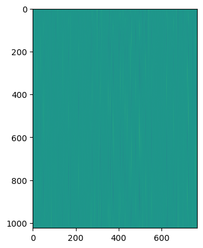

```python
import matplotlib.pyplot as plt
%matplotlib inline
# positional encoding for the first token
plt.imshow(sd_hf['transformer.wpe.weight'])
plt.show()
```

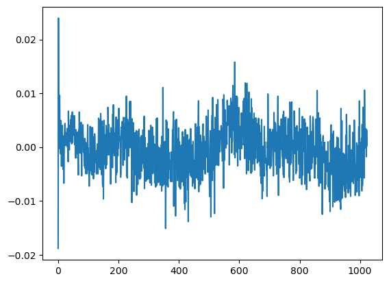

```python
# positional encoding for the first token
plt.plot(sd_hf['transformer.wpe.weight'][:, 0])
plt.show()
```

[figure not shown]

```python
plt.plot(sd_hf['transformer.wpe.weight'][:, 100], label='channel-100')
plt.plot(sd_hf['transformer.wpe.weight'][:, 200], label='channel-200')
plt.plot(sd_hf['transformer.wpe.weight'][:, 250], label='channel-150')
plt.legend()
plt.show()
```

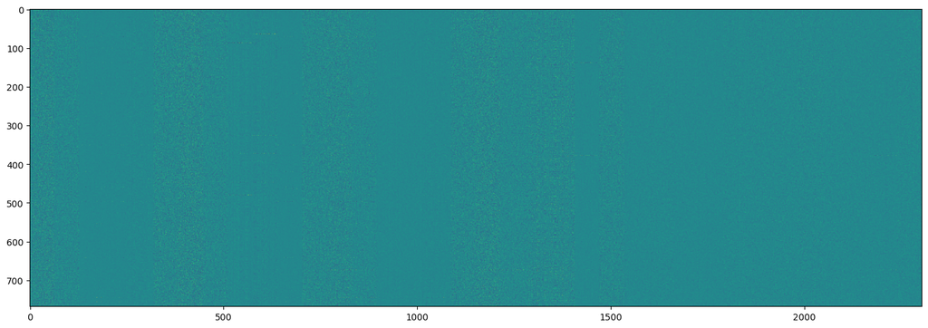

```python
fig, ax = plt.subplots(figsize=(18, 6))
ax.imshow(sd_hf["transformer.h.1.attn.c_attn.weight"])
plt.show()
```

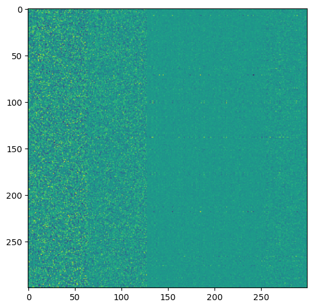

```python
fig, ax = plt.subplots(figsize=(18, 6))
ax.imshow(sd_hf["transformer.h.1.attn.c_attn.weight"][:300,:300])
plt.show()
```

**generating sentence from GPT-2 model.**

```python
from transformers import AutoModel
from transformers import pipeline, set_seed

set_seed(17)
# 1. Just load the pipeline. It will handle loading the model & tokenizer automatically.
generator = pipeline('text-generation', model='gpt2', device=0 if torch.cuda.is_available() else -1)
# 2. Pass the RAW string to the generator.
output = generator(
    "I love Fudan,",
    max_new_tokens=50,    # How many words to add
    truncation=True,      # Cleanly handle long inputs
    pad_token_id=50256    # Stops the "Setting pad_token_id" warning
)
for i, o in enumerate(output):
    print(f"[{i}] {o['generated_text']}")
```

```
[0] I love Fudan, because it's beautiful, it's a lovely place, it is the perfect meal, and it's just like the day before, and everybody goes home at the same time all by itself. And I'm happy and sad and happy and happy and happy
```

GPT-2 architecture:

- GPT class ([nn.ModuleDict](https://pytorch.org/docs/stable/generated/torch.nn.ModuleDict.html), [nn.Embedding](https://pytorch.org/docs/stable/generated/torch.nn.Embedding.html), [nn.ModuleList](https://pytorch.org/docs/stable/generated/torch.nn.ModuleList.html), [nn.LayerNorm](https://pytorch.org/docs/stable/generated/torch.nn.LayerNorm.html))
- Block class (CausalSelfAttention, LayerNorm, MLP)
- CausalSelfAttention class (Dropout, nn.Linear)
- MLP class (nn.Linear, nn.GELU, nn.Dropout)

**Please check GPT-2 v1 code**

### 3.2 Load GPT-2 from source code

```python
from dataclasses import dataclass
import torch
import torch.nn as nn
from torch.nn import functional as F
```

```python
class MLP(nn.Module):

    def __init__(self, config):
        super().__init__()
        self.c_fc    = nn.Linear(config.n_embd, 4 * config.n_embd, bias=config.bias) # matrix of W1
        # GELU paper: https://arxiv.org/pdf/1606.08415
        self.gelu    = nn.GELU() # nonlinear activation function
        self.c_proj  = nn.Linear(4 * config.n_embd, config.n_embd, bias=config.bias) # matrix of W2

    def forward(self, x):
        x = self.c_fc(x)
        x = self.gelu(x)
        x = self.c_proj(x)
        return x
```

```python
class CausalSelfAttention(nn.Module):

    def __init__(self, config):
        super().__init__()
        assert config.n_embd % config.n_head == 0
        # key, query, value projections for all heads, but in a batch
        self.c_attn = nn.Linear(config.n_embd, 3 * config.n_embd, bias=config.bias)
        # output projection
        self.c_proj = nn.Linear(config.n_embd, config.n_embd, bias=config.bias)
        self.n_head = config.n_head
        self.n_embd = config.n_embd
        # This line creates a lower triangular attention mask (often called a causal mask)
        # and registers it as a buffer inside your PyTorch model (not as a parameter).
        self.register_buffer("bias", torch.tril(torch.ones(config.block_size, config.block_size))
                                        .view(1, 1, config.block_size, config.block_size))

    def forward(self, x):
        B, T, C = x.size() # batch size, sequence length, embedding dimensionality (n_embd)

        # calculate query, key, values for all heads in batch and move head forward to be the batch dim
        q, k, v  = self.c_attn(x).split(self.n_embd, dim=2)
        k = k.view(B, T, self.n_head, C // self.n_head).transpose(1, 2) # (B, nh, T, hs)
        q = q.view(B, T, self.n_head, C // self.n_head).transpose(1, 2) # (B, nh, T, hs)
        v = v.view(B, T, self.n_head, C // self.n_head).transpose(1, 2) # (B, nh, T, hs)
        att = (q @ k.transpose(-2, -1)) * (1.0 / math.sqrt(k.size(-1)))
        att = att.masked_fill(self.bias[:,:,:T,:T] == 0, float('-inf'))
        att = F.softmax(att, dim=-1)
        y = att @ v # (B, nh, T, T) x (B, nh, T, hs) -> (B, nh, T, hs)
        y = y.transpose(1, 2).contiguous().view(B, T, C) # re-assemble all head outputs side by side
        # output projection
        y = self.c_proj(y)
        return y
```

```python
class Block(nn.Module):

    def __init__(self, config):
        super().__init__()
        self.ln_1 = nn.LayerNorm(config.n_embd)
        self.attn = CausalSelfAttention(config)
        self.ln_2 = nn.LayerNorm(config.n_embd)
        self.mlp = MLP(config)

    def forward(self, x):
        x = x + self.attn(self.ln_1(x))
        x = x + self.mlp(self.ln_2(x))
        return x
```

```python
@dataclass
class GPTConfig:
    block_size: int = 1024
    vocab_size: int = 50257
    bias: bool = True
    n_layer: int = 12
    n_head: int = 12
    n_embd: int = 768

class GPT(nn.Module):

    def __init__(self, config):
        super().__init__()
        self.config = config

        self.transformer = nn.ModuleDict(
            dict(
                wte = nn.Embedding(config.vocab_size, config.n_embd),
                wpe = nn.Embedding(config.block_size, config.n_embd),
                h = nn.ModuleList([Block(config) for _ in range(config.n_layer)]),
                ln_f = nn.LayerNorm(config.n_embd),
            )
        )
        self.lm_head = nn.Linear(config.n_embd, config.vocab_size, bias=False)


    @classmethod
    def from_pretrained(cls, model_type, override_args=None):
        """Loads pretrained GPT-2 model weights from huggingface. """
        assert model_type in {'gpt2', 'gpt2-medium', 'gpt2-large', 'gpt2-xl'}
        from transformers import GPT2LMHeadModel
        print("loading weights from pretrained gpt: %s" % model_type)

        # n_layer, n_head and n_embd are determined from model_type
        config_args = {
            'gpt2':         dict(n_layer=12, n_head=12, n_embd=768),  # 124M params
            'gpt2-medium':  dict(n_layer=24, n_head=16, n_embd=1024), # 350M params
            'gpt2-large':   dict(n_layer=36, n_head=20, n_embd=1280), # 774M params
            'gpt2-xl':      dict(n_layer=48, n_head=25, n_embd=1600), # 1558M params
        }[model_type]
        print("forcing vocab_size=50257, block_size=1024, bias=True")
        config_args['vocab_size'] = 50257 # always 50257 for GPT model checkpoints
        config_args['block_size'] = 1024 # always 1024 for GPT model checkpoints
        config_args['bias'] = True # always True for GPT model checkpoints
        config = GPTConfig(**config_args)
        model = GPT(config)
        sd = model.state_dict()
        sd_keys = sd.keys()
        sd_keys = [k for k in sd_keys if not k.endswith('.attn.bias')] # discard this mask / buffer, not a param

        # init a huggingface/transformers model
        model_hf = GPT2LMHeadModel.from_pretrained(model_type)
        sd_hf = model_hf.state_dict()

        # copy while ensuring all of the parameters are aligned and match in names and shapes
        sd_keys_hf = sd_hf.keys()
        sd_keys_hf = [k for k in sd_keys_hf if not k.endswith('.attn.masked_bias')] # ignore these, just a buffer
        sd_keys_hf = [k for k in sd_keys_hf if not k.endswith('.attn.bias')] # same, just the mask (buffer)
        transposed = ['attn.c_attn.weight', 'attn.c_proj.weight', 'mlp.c_fc.weight', 'mlp.c_proj.weight']
        # basically the openai checkpoints use a "Conv1D" module, but we only want to use a vanilla Linear
        # this means that we have to transpose these weights when we import them
        assert len(sd_keys_hf) == len(sd_keys), f"mismatched keys: {len(sd_keys_hf)} != {len(sd_keys)}"
        for k in sd_keys_hf:
            if any(k.endswith(w) for w in transposed):
                # special treatment for the Conv1D weights we need to transpose
                assert sd_hf[k].shape[::-1] == sd[k].shape
                with torch.no_grad():
                    sd[k].copy_(sd_hf[k].t())
            else:
                # vanilla copy over the other parameters
                assert sd_hf[k].shape == sd[k].shape
                with torch.no_grad():
                    sd[k].copy_(sd_hf[k])

        return model

model= GPT.from_pretrained('gpt2')
print('Successfully load the model from GPT-2 to ours!')
```

```
loading weights from pretrained gpt: gpt2
forcing vocab_size=50257, block_size=1024, bias=True
Successfully load the model from GPT-2 to ours!
```

### 3.3 Sampling from GTP-2 initial

```python
from transformers import GPT2LMHeadModel
# Choose your model_type, e.g., 'gpt2'
model_type = 'gpt2'
model_hf = GPT2LMHeadModel.from_pretrained(model_type)
model_hf.save_pretrained(f"./{model_type}_weights")
```

```python
from dataclasses import dataclass
import torch
import torch.nn as nn
from torch.nn import functional as F

class CausalSelfAttention(nn.Module):

    def __init__(self, config):
        super().__init__()
        assert config.n_embd % config.n_head == 0
        # key, query, value projections for all heads, but in a batch
        self.c_attn = nn.Linear(config.n_embd, 3 * config.n_embd, bias=config.bias)
        # output projection
        self.c_proj = nn.Linear(config.n_embd, config.n_embd, bias=config.bias)
        self.n_head = config.n_head
        self.n_embd = config.n_embd
        self.register_buffer("bias", torch.tril(torch.ones(config.block_size, config.block_size))
                                        .view(1, 1, config.block_size, config.block_size))

    def forward(self, x):
        B, T, C = x.size() # batch size, sequence length, embedding dimensionality (n_embd)

        # calculate query, key, values for all heads in batch and move head forward to be the batch dim
        q, k, v  = self.c_attn(x).split(self.n_embd, dim=2)
        k = k.view(B, T, self.n_head, C // self.n_head).transpose(1, 2) # (B, nh, T, hs)
        q = q.view(B, T, self.n_head, C // self.n_head).transpose(1, 2) # (B, nh, T, hs)
        v = v.view(B, T, self.n_head, C // self.n_head).transpose(1, 2) # (B, nh, T, hs)
        att = (q @ k.transpose(-2, -1)) * (1.0 / math.sqrt(k.size(-1)))
        att = att.masked_fill(self.bias[:,:,:T,:T] == 0, float('-inf'))
        att = F.softmax(att, dim=-1)
        y = att @ v # (B, nh, T, T) x (B, nh, T, hs) -> (B, nh, T, hs)
        y = y.transpose(1, 2).contiguous().view(B, T, C) # re-assemble all head outputs side by side
        # output projection
        y = self.c_proj(y)
        return y


class Block(nn.Module):

    def __init__(self, config):
        super().__init__()
        self.ln_1 = nn.LayerNorm(config.n_embd)
        self.attn = CausalSelfAttention(config)
        self.ln_2 = nn.LayerNorm(config.n_embd)
        self.mlp = MLP(config)

    def forward(self, x):
        x = x + self.attn(self.ln_1(x))
        x = x + self.mlp(self.ln_2(x))
        return x

@dataclass
class GPTConfig:
    block_size: int = 1024
    vocab_size: int = 50257
    bias: bool = True
    n_layer: int = 12
    n_head: int = 12
    n_embd: int = 768

class GPT(nn.Module):

    def __init__(self, config):
        super().__init__()
        self.config = config

        self.transformer = nn.ModuleDict(
            dict(
                wte = nn.Embedding(config.vocab_size, config.n_embd),
                wpe = nn.Embedding(config.block_size, config.n_embd),
                h = nn.ModuleList([Block(config) for _ in range(config.n_layer)]),
                ln_f = nn.LayerNorm(config.n_embd),
            )
        )
        self.lm_head = nn.Linear(config.n_embd, config.vocab_size, bias=False)

    def forward(self, idx, targets=None):
        b, t = idx.size() # (B, T)
        assert t <= self.config.block_size, f"Cannot forward sequence of length {t}, block size is only {self.config.block_size}"
        pos = torch.arange(0, t, dtype=torch.long, device=device) # shape (t)
        tok_emb = self.transformer.wte(idx) # token embeddings of shape (b, t, n_embd)
        pos_emb = self.transformer.wpe(pos) # position embeddings of shape (t, n_embd)
        x = tok_emb + pos_emb
        for block in self.transformer.h:
            x = block(x)
        x = self.transformer.ln_f(x)
        logits = self.lm_head(x)
        return logits


    @classmethod
    def from_pretrained(cls, model_type, override_args=None):
        """Loads pretrained GPT-2 model weights from huggingface. """
        assert model_type in {'gpt2', 'gpt2-medium', 'gpt2-large', 'gpt2-xl'}
        from transformers import GPT2LMHeadModel
        print("loading weights from pretrained gpt: %s" % model_type)

        # n_layer, n_head and n_embd are determined from model_type
        config_args = {
            'gpt2':         dict(n_layer=12, n_head=12, n_embd=768),  # 124M params
            'gpt2-medium':  dict(n_layer=24, n_head=16, n_embd=1024), # 350M params
            'gpt2-large':   dict(n_layer=36, n_head=20, n_embd=1280), # 774M params
            'gpt2-xl':      dict(n_layer=48, n_head=25, n_embd=1600), # 1558M params
        }[model_type]
        print("forcing vocab_size=50257, block_size=1024, bias=True")
        config_args['vocab_size'] = 50257 # always 50257 for GPT model checkpoints
        config_args['block_size'] = 1024 # always 1024 for GPT model checkpoints
        config_args['bias'] = True # always True for GPT model checkpoints
        config = GPTConfig(**config_args)
        model = GPT(config)
        sd = model.state_dict()
        sd_keys = sd.keys()
        sd_keys = [k for k in sd_keys if not k.endswith('.attn.bias')] # discard this mask / buffer, not a param

        # init a huggingface/transformers model
        model_hf = GPT2LMHeadModel.from_pretrained(f"./{model_type}_weights")
        sd_hf = model_hf.state_dict()

        # copy while ensuring all of the parameters are aligned and match in names and shapes
        sd_keys_hf = sd_hf.keys()
        sd_keys_hf = [k for k in sd_keys_hf if not k.endswith('.attn.masked_bias')] # ignore these, just a buffer
        sd_keys_hf = [k for k in sd_keys_hf if not k.endswith('.attn.bias')] # same, just the mask (buffer)
        transposed = ['attn.c_attn.weight', 'attn.c_proj.weight', 'mlp.c_fc.weight', 'mlp.c_proj.weight']
        # basically the openai checkpoints use a "Conv1D" module, but we only want to use a vanilla Linear
        # this means that we have to transpose these weights when we import them
        assert len(sd_keys_hf) == len(sd_keys), f"mismatched keys: {len(sd_keys_hf)} != {len(sd_keys)}"
        for k in sd_keys_hf:
            if any(k.endswith(w) for w in transposed):
                # special treatment for the Conv1D weights we need to transpose
                assert sd_hf[k].shape[::-1] == sd[k].shape
                with torch.no_grad():
                    sd[k].copy_(sd_hf[k].t())
            else:
                # vanilla copy over the other parameters
                assert sd_hf[k].shape == sd[k].shape
                with torch.no_grad():
                    sd[k].copy_(sd_hf[k])

        return model
```

```python
num_return_sequences = 5
max_length = 30
model = GPT.from_pretrained('gpt2')
model.eval()
model.to('cuda')
```

```
loading weights from pretrained gpt: gpt2
forcing vocab_size=50257, block_size=1024, bias=True
```

```
GPT(
  (transformer): ModuleDict(
    (wte): Embedding(50257, 768)
    (wpe): Embedding(1024, 768)
    (h): ModuleList(
      (0-11): 12 x Block(
        (ln_1): LayerNorm((768,), eps=1e-05, elementwise_affine=True)
        (attn): CausalSelfAttention(
          (c_attn): Linear(in_features=768, out_features=2304, bias=True)
          (c_proj): Linear(in_features=768, out_features=768, bias=True)
        )
        (ln_2): LayerNorm((768,), eps=1e-05, elementwise_affine=True)
        (mlp): MLP(
          (c_fc): Linear(in_features=768, out_features=3072, bias=True)
          (gelu): GELU(approximate='none')
          (c_proj): Linear(in_features=3072, out_features=768, bias=True)
        )
      )
    )
    (ln_f): LayerNorm((768,), eps=1e-05, elementwise_affine=True)
  )
  (lm_head): Linear(in_features=768, out_features=50257, bias=False)
)
```

```python
from transformers import GPT2Tokenizer
# Point it to your local directory
tokenizer = GPT2Tokenizer.from_pretrained("./gpt2_weights")
tokens = tokenizer.encode("Hello, I'm a language model,")
print(tokens)
tokens = torch.tensor(tokens, dtype=torch.long) # (8,)
tokens = tokens.unsqueeze(0).repeat(num_return_sequences, 1) # (5,8)
x = tokens.to('cuda')
```

```
[15496, 11, 314, 1101, 257, 3303, 2746, 11]
```

```python
import math
# generate! right now x is (B, T) where B = 5, T = 8
# set the seed to 42
device = 'cuda'
torch.manual_seed(42)
# torch.cuda.manual_seed(42)
print(x.size(1), max_length)
while x.size(1) < max_length:
    # forward the model to get the logits
    with torch.no_grad():
        logits = model(x) # (B, T, vocab_size)
        # take the logits at the last position
        logits = logits[:, -1, :] # (B, vocab_size)
        # get the probabilities
        probs = F.softmax(logits, dim=-1)
        # do top-k sampling of 50 (huggingface pipeline default)
        # topk_probs here becomes (5, 50), topk_indices is (5, 50)
        topk_probs, topk_indices = torch.topk(probs, 50, dim=-1)
        print(probs.shape, topk_probs.shape, topk_probs[0,:].sum())
        # select a token from the top-k probabilities
        ix = torch.multinomial(topk_probs, 1) # (B, 1)
        # gather the corresponding indices
        xcol = torch.gather(topk_indices, -1, ix) # (B, 1)
        # append to the sequence
        x = torch.cat((x, xcol), dim=1)
        print(x.shape)

for i in range(num_return_sequences):
    tokens = x[i, :max_length].tolist()
    decoded = tokenizer.decode(tokens)
    print(">", decoded)
```

```
8 30
torch.Size([5, 50257]) torch.Size([5, 50]) tensor(0.8060, device='cuda:0')
torch.Size([5, 9])
torch.Size([5, 50257]) torch.Size([5, 50]) tensor(0.9104, device='cuda:0')
torch.Size([5, 10])
torch.Size([5, 50257]) torch.Size([5, 50]) tensor(0.5246, device='cuda:0')
torch.Size([5, 11])
torch.Size([5, 50257]) torch.Size([5, 50]) tensor(0.8912, device='cuda:0')
torch.Size([5, 12])
torch.Size([5, 50257]) torch.Size([5, 50]) tensor(0.8049, device='cuda:0')
torch.Size([5, 13])
torch.Size([5, 50257]) torch.Size([5, 50]) tensor(0.9985, device='cuda:0')
torch.Size([5, 14])
torch.Size([5, 50257]) torch.Size([5, 50]) tensor(0.5723, device='cuda:0')
torch.Size([5, 15])
torch.Size([5, 50257]) torch.Size([5, 50]) tensor(0.8651, device='cuda:0')
torch.Size([5, 16])
torch.Size([5, 50257]) torch.Size([5, 50]) tensor(0.6959, device='cuda:0')
torch.Size([5, 17])
torch.Size([5, 50257]) torch.Size([5, 50]) tensor(0.9391, device='cuda:0')
torch.Size([5, 18])
torch.Size([5, 50257]) torch.Size([5, 50]) tensor(0.7163, device='cuda:0')
torch.Size([5, 19])
torch.Size([5, 50257]) torch.Size([5, 50]) tensor(0.7760, device='cuda:0')
torch.Size([5, 20])
torch.Size([5, 50257]) torch.Size([5, 50]) tensor(0.6119, device='cuda:0')
torch.Size([5, 21])
torch.Size([5, 50257]) torch.Size([5, 50]) tensor(0.8034, device='cuda:0')
torch.Size([5, 22])
torch.Size([5, 50257]) torch.Size([5, 50]) tensor(0.4333, device='cuda:0')
torch.Size([5, 23])
torch.Size([5, 50257]) torch.Size([5, 50]) tensor(0.9051, device='cuda:0')
torch.Size([5, 24])
torch.Size([5, 50257]) torch.Size([5, 50]) tensor(0.5499, device='cuda:0')
torch.Size([5, 25])
torch.Size([5, 50257]) torch.Size([5, 50]) tensor(0.3917, device='cuda:0')
torch.Size([5, 26])
torch.Size([5, 50257]) torch.Size([5, 50]) tensor(0.9459, device='cuda:0')
torch.Size([5, 27])
torch.Size([5, 50257]) torch.Size([5, 50]) tensor(0.8620, device='cuda:0')
torch.Size([5, 28])
torch.Size([5, 50257]) torch.Size([5, 50]) tensor(0.8422, device='cuda:0')
torch.Size([5, 29])
torch.Size([5, 50257]) torch.Size([5, 50]) tensor(0.7195, device='cuda:0')
torch.Size([5, 30])
> Hello, I'm a language model, not a program.

So this morning I started studying for the interview in the lab. This was not
> Hello, I'm a language model, and one of the reasons I love studying languages, to think that it can be a lot easier for those who
> Hello, I'm a language model, and I wrote it off on the grounds that a language model would make me more fluent. But I'm not
> Hello, I'm a language model, I really like languages. I like languages because like, they're good. And the way we talk about languages
> Hello, I'm a language model, a language model I'm using for data modelling. All I did was test the results and then I wrote some
```

### 3.4 Sampling from random model

- We only need to change the code code from

```
  model = GPT.from_pretrained('gpt2')
```

into

```
  model = GPT(GPTConfig())
```

```python
from dataclasses import dataclass
import torch
import torch.nn as nn
from torch.nn import functional as F
from transformers import GPT2Tokenizer

class MLP(nn.Module):

    def __init__(self, config):
        super().__init__()
        self.c_fc    = nn.Linear(config.n_embd, 4 * config.n_embd, bias=config.bias) # matrix of W1
        # GELU paper: https://arxiv.org/pdf/1606.08415
        self.gelu    = nn.GELU() # nonlinear activation function
        self.c_proj  = nn.Linear(4 * config.n_embd, config.n_embd, bias=config.bias) # matrix of W2

    def forward(self, x):
        x = self.c_fc(x)
        x = self.gelu(x)
        x = self.c_proj(x)
        return x

class CausalSelfAttention(nn.Module):

    def __init__(self, config):
        super().__init__()
        assert config.n_embd % config.n_head == 0
        # key, query, value projections for all heads, but in a batch
        self.c_attn = nn.Linear(config.n_embd, 3 * config.n_embd, bias=config.bias)
        # output projection
        self.c_proj = nn.Linear(config.n_embd, config.n_embd, bias=config.bias)
        self.n_head = config.n_head
        self.n_embd = config.n_embd
        self.register_buffer("bias", torch.tril(torch.ones(config.block_size, config.block_size))
                                        .view(1, 1, config.block_size, config.block_size))

    def forward(self, x):
        B, T, C = x.size() # batch size, sequence length, embedding dimensionality (n_embd)

        # calculate query, key, values for all heads in batch and move head forward to be the batch dim
        q, k, v  = self.c_attn(x).split(self.n_embd, dim=2)
        k = k.view(B, T, self.n_head, C // self.n_head).transpose(1, 2) # (B, nh, T, hs)
        q = q.view(B, T, self.n_head, C // self.n_head).transpose(1, 2) # (B, nh, T, hs)
        v = v.view(B, T, self.n_head, C // self.n_head).transpose(1, 2) # (B, nh, T, hs)
        att = (q @ k.transpose(-2, -1)) * (1.0 / math.sqrt(k.size(-1)))
        att = att.masked_fill(self.bias[:,:,:T,:T] == 0, float('-inf'))
        att = F.softmax(att, dim=-1)
        y = att @ v # (B, nh, T, T) x (B, nh, T, hs) -> (B, nh, T, hs)
        y = y.transpose(1, 2).contiguous().view(B, T, C) # re-assemble all head outputs side by side
        # output projection
        y = self.c_proj(y)
        return y


class Block(nn.Module):

    def __init__(self, config):
        super().__init__()
        self.ln_1 = nn.LayerNorm(config.n_embd)
        self.attn = CausalSelfAttention(config)
        self.ln_2 = nn.LayerNorm(config.n_embd)
        self.mlp = MLP(config)

    def forward(self, x):
        x = x + self.attn(self.ln_1(x))
        x = x + self.mlp(self.ln_2(x))
        return x

@dataclass
class GPTConfig:
    block_size: int = 1024
    vocab_size: int = 50257
    bias: bool = True
    n_layer: int = 12
    n_head: int = 12
    n_embd: int = 768

class GPT(nn.Module):

    def __init__(self, config):
        super().__init__()
        self.config = config

        self.transformer = nn.ModuleDict(
            dict(
                wte = nn.Embedding(config.vocab_size, config.n_embd),
                wpe = nn.Embedding(config.block_size, config.n_embd),
                h = nn.ModuleList([Block(config) for _ in range(config.n_layer)]),
                ln_f = nn.LayerNorm(config.n_embd),
            )
        )
        self.lm_head = nn.Linear(config.n_embd, config.vocab_size, bias=False)

    def forward(self, idx, targets=None):
        b, t = idx.size() # (B, T)
        assert t <= self.config.block_size, f"Cannot forward sequence of length {t}, block size is only {self.config.block_size}"
        pos = torch.arange(0, t, dtype=torch.long, device=device) # shape (t)
        tok_emb = self.transformer.wte(idx) # token embeddings of shape (b, t, n_embd)
        pos_emb = self.transformer.wpe(pos) # position embeddings of shape (t, n_embd)
        x = tok_emb + pos_emb
        for block in self.transformer.h:
            x = block(x)
        x = self.transformer.ln_f(x)
        logits = self.lm_head(x)
        return logits


    @classmethod
    def from_pretrained(cls, model_type, override_args=None):
        """Loads pretrained GPT-2 model weights from huggingface. """
        assert model_type in {'gpt2', 'gpt2-medium', 'gpt2-large', 'gpt2-xl'}
        from transformers import GPT2LMHeadModel
        print("loading weights from pretrained gpt: %s" % model_type)

        # n_layer, n_head and n_embd are determined from model_type
        config_args = {
            'gpt2':         dict(n_layer=12, n_head=12, n_embd=768),  # 124M params
            'gpt2-medium':  dict(n_layer=24, n_head=16, n_embd=1024), # 350M params
            'gpt2-large':   dict(n_layer=36, n_head=20, n_embd=1280), # 774M params
            'gpt2-xl':      dict(n_layer=48, n_head=25, n_embd=1600), # 1558M params
        }[model_type]
        print("forcing vocab_size=50257, block_size=1024, bias=True")
        config_args['vocab_size'] = 50257 # always 50257 for GPT model checkpoints
        config_args['block_size'] = 1024 # always 1024 for GPT model checkpoints
        config_args['bias'] = True # always True for GPT model checkpoints
        config = GPTConfig(**config_args)
        model = GPT(config)
        sd = model.state_dict()
        sd_keys = sd.keys()
        sd_keys = [k for k in sd_keys if not k.endswith('.attn.bias')] # discard this mask / buffer, not a param

        # init a huggingface/transformers model
        model_hf = GPT2LMHeadModel.from_pretrained(model_type)
        sd_hf = model_hf.state_dict()

        # copy while ensuring all of the parameters are aligned and match in names and shapes
        sd_keys_hf = sd_hf.keys()
        sd_keys_hf = [k for k in sd_keys_hf if not k.endswith('.attn.masked_bias')] # ignore these, just a buffer
        sd_keys_hf = [k for k in sd_keys_hf if not k.endswith('.attn.bias')] # same, just the mask (buffer)
        transposed = ['attn.c_attn.weight', 'attn.c_proj.weight', 'mlp.c_fc.weight', 'mlp.c_proj.weight']
        # basically the openai checkpoints use a "Conv1D" module, but we only want to use a vanilla Linear
        # this means that we have to transpose these weights when we import them
        assert len(sd_keys_hf) == len(sd_keys), f"mismatched keys: {len(sd_keys_hf)} != {len(sd_keys)}"
        for k in sd_keys_hf:
            if any(k.endswith(w) for w in transposed):
                # special treatment for the Conv1D weights we need to transpose
                assert sd_hf[k].shape[::-1] == sd[k].shape
                with torch.no_grad():
                    sd[k].copy_(sd_hf[k].t())
            else:
                # vanilla copy over the other parameters
                assert sd_hf[k].shape == sd[k].shape
                with torch.no_grad():
                    sd[k].copy_(sd_hf[k])

        return model

num_return_sequences = 5
max_length = 30
model = GPT(GPTConfig())
model.eval()
model.to('cuda')
tokenizer = GPT2Tokenizer.from_pretrained("./gpt2_weights")

tokens = tokenizer.encode("Hello, I'am a language model,")
tokens = torch.tensor(tokens, dtype=torch.long) # (8,)
tokens = tokens.unsqueeze(0).repeat(num_return_sequences, 1) # (5,8)
# x = tokens.to('cuda')
x = tokens.to('cuda')  # change to GPU, if you have any.

device = 'cuda'
torch.manual_seed(42)
# torch.cuda.manual_seed(42)
print(x.size(1), max_length)
while x.size(1) < max_length:
    # forward the model to get the logits
    with torch.no_grad():
        logits = model(x) # (B, T, vocab_size)
        # take the logits at the last position
        logits = logits[:, -1, :] # (B, vocab_size)
        # get the probabilities
        probs = F.softmax(logits, dim=-1)
        # do top-k sampling of 50 (huggingface pipeline default)
        # topk_probs here becomes (5, 50), topk_indices is (5, 50)
        topk_probs, topk_indices = torch.topk(probs, 50, dim=-1)
        print(probs.shape, topk_probs.shape, topk_probs[0,:].sum())
        # select a token from the top-k probabilities
        ix = torch.multinomial(topk_probs, 1) # (B, 1)
        # gather the corresponding indices
        xcol = torch.gather(topk_indices, -1, ix) # (B, 1)
        # append to the sequence
        x = torch.cat((x, xcol), dim=1)

for i in range(num_return_sequences):
    tokens = x[i, :max_length].tolist()
    decoded = tokenizer.decode(tokens)
    print(">", decoded)
```

```
9 30
torch.Size([5, 50257]) torch.Size([5, 50]) tensor(0.0061, device='cuda:0')
torch.Size([5, 50257]) torch.Size([5, 50]) tensor(0.0059, device='cuda:0')
torch.Size([5, 50257]) torch.Size([5, 50]) tensor(0.0058, device='cuda:0')
torch.Size([5, 50257]) torch.Size([5, 50]) tensor(0.0062, device='cuda:0')
torch.Size([5, 50257]) torch.Size([5, 50]) tensor(0.0058, device='cuda:0')
torch.Size([5, 50257]) torch.Size([5, 50]) tensor(0.0056, device='cuda:0')
torch.Size([5, 50257]) torch.Size([5, 50]) tensor(0.0061, device='cuda:0')
torch.Size([5, 50257]) torch.Size([5, 50]) tensor(0.0061, device='cuda:0')
torch.Size([5, 50257]) torch.Size([5, 50]) tensor(0.0059, device='cuda:0')
torch.Size([5, 50257]) torch.Size([5, 50]) tensor(0.0061, device='cuda:0')
torch.Size([5, 50257]) torch.Size([5, 50]) tensor(0.0064, device='cuda:0')
torch.Size([5, 50257]) torch.Size([5, 50]) tensor(0.0057, device='cuda:0')
torch.Size([5, 50257]) torch.Size([5, 50]) tensor(0.0061, device='cuda:0')
torch.Size([5, 50257]) torch.Size([5, 50]) tensor(0.0057, device='cuda:0')
torch.Size([5, 50257]) torch.Size([5, 50]) tensor(0.0055, device='cuda:0')
torch.Size([5, 50257]) torch.Size([5, 50]) tensor(0.0059, device='cuda:0')
torch.Size([5, 50257]) torch.Size([5, 50]) tensor(0.0059, device='cuda:0')
torch.Size([5, 50257]) torch.Size([5, 50]) tensor(0.0058, device='cuda:0')
torch.Size([5, 50257]) torch.Size([5, 50]) tensor(0.0057, device='cuda:0')
torch.Size([5, 50257]) torch.Size([5, 50]) tensor(0.0059, device='cuda:0')
torch.Size([5, 50257]) torch.Size([5, 50]) tensor(0.0060, device='cuda:0')
> Hello, I'am a language model,arg systematically chartingly GPUs affiliate meltdownthinkableRest scheduling Bigfoot{\ Toggle slopes incidentalisites dollGMTInst occult Congressional
> Hello, I'am a language model, AngolaAA enrollment Obst�", torqueTPP containment Munurses dazzling deprived ridicule positioning pervasivereements tornado voicing593phi
> Hello, I'am a language model,Termin Links lawful crit DCibility Flex 神 panic Weber DefendantsAssuming Embestingotidearch prosecutingfitios 231 lug
> Hello, I'am a language model, maintained Barry SpoilerFFFF theolog248engertheGo PsyFair subordinatevati closingizza guaranteed VICE Vegaslatagu stations
> Hello, I'am a language model, Talk PlayStation ord adv Canaveral additaminportation socket ZurichATTLEPoll collecting blastsColaul Zoe──── Docker scrib Indust
```

## 3. Train GPT-2 model using Shakespeare dataset

```python
# read it in to inspect it
with open('input.txt', 'r', encoding='utf-8') as f:
    text = f.read()
data = text[:200]
print(data)
```

```
First Citizen:
Before we proceed any further, hear me speak.

All:
Speak, speak.

First Citizen:
You are all resolved rather to die than to famish?

All:
Resolved. resolved.

First Citizen:
First, you
```

```python
tokenizer = GPT2Tokenizer.from_pretrained("./gpt2_weights")
tokens = tokenizer.encode(data)
print(tokens[:24])
buf = torch.tensor(tokens[:24])
x = buf.view(4, 6)
print(x)
```

```
[5962, 22307, 25, 198, 8421, 356, 5120, 597, 2252, 11, 3285, 502, 2740, 13, 198, 198, 3237, 25, 198, 5248, 461, 11, 2740, 13]
tensor([[ 5962, 22307,    25,   198,  8421,   356],
        [ 5120,   597,  2252,    11,  3285,   502],
        [ 2740,    13,   198,   198,  3237,    25],
        [  198,  5248,   461,    11,  2740,    13]])
```

```python
# data sample x and label y
buf = torch.tensor(tokens[:24 + 1])
x = buf[:-1].view(4, 6)
y = buf[1:].view(4, 6)
print(x)
print(y)
```

```
tensor([[ 5962, 22307,    25,   198,  8421,   356],
        [ 5120,   597,  2252,    11,  3285,   502],
        [ 2740,    13,   198,   198,  3237,    25],
        [  198,  5248,   461,    11,  2740,    13]])
tensor([[22307,    25,   198,  8421,   356,  5120],
        [  597,  2252,    11,  3285,   502,  2740],
        [   13,   198,   198,  3237,    25,   198],
        [ 5248,   461,    11,  2740,    13,   198]])
```

### 3.1 Form a batch and put it into GPT-2 and then output logits

```python
import math
from dataclasses import dataclass
import torch
import torch.nn as nn
from torch.nn import functional as F
from transformers import GPT2Tokenizer


class MLP(nn.Module):

    def __init__(self, config):
        super().__init__()
        self.c_fc    = nn.Linear(config.n_embd, 4 * config.n_embd, bias=config.bias) # matrix of W1
        # GELU paper: https://arxiv.org/pdf/1606.08415
        self.gelu    = nn.GELU() # nonlinear activation function
        self.c_proj  = nn.Linear(4 * config.n_embd, config.n_embd, bias=config.bias) # matrix of W2

    def forward(self, x):
        x = self.c_fc(x)
        x = self.gelu(x)
        x = self.c_proj(x)
        return x

class CausalSelfAttention(nn.Module):

    def __init__(self, config):
        super().__init__()
        assert config.n_embd % config.n_head == 0
        # key, query, value projections for all heads, but in a batch
        self.c_attn = nn.Linear(config.n_embd, 3 * config.n_embd, bias=config.bias)
        # output projection
        self.c_proj = nn.Linear(config.n_embd, config.n_embd, bias=config.bias)
        self.n_head = config.n_head
        self.n_embd = config.n_embd
        self.register_buffer("bias", torch.tril(torch.ones(config.block_size, config.block_size))
                                        .view(1, 1, config.block_size, config.block_size))

    def forward(self, x):
        B, T, C = x.size() # batch size, sequence length, embedding dimensionality (n_embd)

        # calculate query, key, values for all heads in batch and move head forward to be the batch dim
        q, k, v  = self.c_attn(x).split(self.n_embd, dim=2)
        k = k.view(B, T, self.n_head, C // self.n_head).transpose(1, 2) # (B, nh, T, hs)
        q = q.view(B, T, self.n_head, C // self.n_head).transpose(1, 2) # (B, nh, T, hs)
        v = v.view(B, T, self.n_head, C // self.n_head).transpose(1, 2) # (B, nh, T, hs)
        att = (q @ k.transpose(-2, -1)) * (1.0 / math.sqrt(k.size(-1)))
        att = att.masked_fill(self.bias[:,:,:T,:T] == 0, float('-inf'))
        att = F.softmax(att, dim=-1)
        y = att @ v # (B, nh, T, T) x (B, nh, T, hs) -> (B, nh, T, hs)
        y = y.transpose(1, 2).contiguous().view(B, T, C) # re-assemble all head outputs side by side
        # output projection
        y = self.c_proj(y)
        return y


class Block(nn.Module):

    def __init__(self, config):
        super().__init__()
        self.ln_1 = nn.LayerNorm(config.n_embd)
        self.attn = CausalSelfAttention(config)
        self.ln_2 = nn.LayerNorm(config.n_embd)
        self.mlp = MLP(config)

    def forward(self, x):
        x = x + self.attn(self.ln_1(x))
        x = x + self.mlp(self.ln_2(x))
        return x

@dataclass
class GPTConfig:
    block_size: int = 1024
    vocab_size: int = 50257
    bias: bool = True
    n_layer: int = 12
    n_head: int = 12
    n_embd: int = 768

class GPT(nn.Module):

    def __init__(self, config):
        super().__init__()
        self.config = config

        self.transformer = nn.ModuleDict(
            dict(
                wte = nn.Embedding(config.vocab_size, config.n_embd),
                wpe = nn.Embedding(config.block_size, config.n_embd),
                h = nn.ModuleList([Block(config) for _ in range(config.n_layer)]),
                ln_f = nn.LayerNorm(config.n_embd),
            )
        )
        self.lm_head = nn.Linear(config.n_embd, config.vocab_size, bias=False)

    def forward(self, idx, targets=None):
        b, t = idx.size() # (B, T)
        assert t <= self.config.block_size, f"Cannot forward sequence of length {t}, block size is only {self.config.block_size}"
        pos = torch.arange(0, t, dtype=torch.long, device=device) # shape (t)
        tok_emb = self.transformer.wte(idx) # token embeddings of shape (b, t, n_embd)
        pos_emb = self.transformer.wpe(pos) # position embeddings of shape (t, n_embd)
        x = tok_emb + pos_emb
        for block in self.transformer.h:
            x = block(x)
        x = self.transformer.ln_f(x)
        logits = self.lm_head(x)
        loss = None
        if targets is not None:
            loss = F.cross_entropy(logits.view(-1, logits.size(-1)), targets.view(-1))
        return logits, loss


    @classmethod
    def from_pretrained(cls, model_type, override_args=None):
        """Loads pretrained GPT-2 model weights from huggingface. """
        assert model_type in {'gpt2', 'gpt2-medium', 'gpt2-large', 'gpt2-xl'}
        from transformers import GPT2LMHeadModel
        print("loading weights from pretrained gpt: %s" % model_type)

        # n_layer, n_head and n_embd are determined from model_type
        config_args = {
            'gpt2':         dict(n_layer=12, n_head=12, n_embd=768),  # 124M params
            'gpt2-medium':  dict(n_layer=24, n_head=16, n_embd=1024), # 350M params
            'gpt2-large':   dict(n_layer=36, n_head=20, n_embd=1280), # 774M params
            'gpt2-xl':      dict(n_layer=48, n_head=25, n_embd=1600), # 1558M params
        }[model_type]
        print("forcing vocab_size=50257, block_size=1024, bias=True")
        config_args['vocab_size'] = 50257 # always 50257 for GPT model checkpoints
        config_args['block_size'] = 1024 # always 1024 for GPT model checkpoints
        config_args['bias'] = True # always True for GPT model checkpoints
        config = GPTConfig(**config_args)
        model = GPT(config)
        sd = model.state_dict()
        sd_keys = sd.keys()
        sd_keys = [k for k in sd_keys if not k.endswith('.attn.bias')] # discard this mask / buffer, not a param

        # init a huggingface/transformers model
        model_hf = GPT2LMHeadModel.from_pretrained(model_type)
        sd_hf = model_hf.state_dict()

        # copy while ensuring all of the parameters are aligned and match in names and shapes
        sd_keys_hf = sd_hf.keys()
        sd_keys_hf = [k for k in sd_keys_hf if not k.endswith('.attn.masked_bias')] # ignore these, just a buffer
        sd_keys_hf = [k for k in sd_keys_hf if not k.endswith('.attn.bias')] # same, just the mask (buffer)
        transposed = ['attn.c_attn.weight', 'attn.c_proj.weight', 'mlp.c_fc.weight', 'mlp.c_proj.weight']
        # basically the openai checkpoints use a "Conv1D" module, but we only want to use a vanilla Linear
        # this means that we have to transpose these weights when we import them
        assert len(sd_keys_hf) == len(sd_keys), f"mismatched keys: {len(sd_keys_hf)} != {len(sd_keys)}"
        for k in sd_keys_hf:
            if any(k.endswith(w) for w in transposed):
                # special treatment for the Conv1D weights we need to transpose
                assert sd_hf[k].shape[::-1] == sd[k].shape
                with torch.no_grad():
                    sd[k].copy_(sd_hf[k].t())
            else:
                # vanilla copy over the other parameters
                assert sd_hf[k].shape == sd[k].shape
                with torch.no_grad():
                    sd[k].copy_(sd_hf[k])

        return model

# attempt to autodetect the device
device = "cpu"
if torch.cuda.is_available():
    device = "cuda"
elif hasattr(torch.backends, "mps") and torch.backends.mps.is_available():
    device = "mps"
else:
    device = "cpu"

num_return_sequences = 5
max_length = 30
model = GPT(GPTConfig())
model.eval()
model.to(device)

import math
tokenizer = GPT2Tokenizer.from_pretrained("./gpt2_weights")
tokens = tokenizer.encode("Hello, I'am a language model,")
tokens = torch.tensor(tokens, dtype=torch.long) # (8,)
tokens = tokens.unsqueeze(0).repeat(num_return_sequences, 1) # (5,8)
# x = tokens.to('cuda')
x = tokens.to(device)

print(f"using device: {device}")
with open('input.txt', 'r') as f:
    text = f.read()
text = text[:1000]
tokens = tokenizer.encode(text)
B, T = 4, 32
buf = torch.tensor(tokens[:B*T + 1])
x = buf[:-1].view(B, T).to(device)  # ← move to device
y = buf[1:].view(B, T).to(device)   # ← move to device
# get logits
model = GPT(GPTConfig())
model.to(device)
logits, loss = model(x)
print(logits.shape, loss)

logits, loss = model(x, y)
print(logits.shape, loss)
```

```
using device: cuda
torch.Size([4, 32, 50257]) None
torch.Size([4, 32, 50257]) tensor(11.0398, device='cuda:0', grad_fn=<NllLossBackward0>)
```

**get loss**

```python
import numpy as np
print(np.log(1/50257.))
```

```
-10.82490511970208
```

### 3.2 Training the model via AdamW single batch

```python
from dataclasses import dataclass
import torch
import torch.nn as nn
from torch.nn import functional as F

class MLP(nn.Module):

    def __init__(self, config):
        super().__init__()
        self.c_fc    = nn.Linear(config.n_embd, 4 * config.n_embd, bias=config.bias) # matrix of W1
        # GELU paper: https://arxiv.org/pdf/1606.08415
        self.gelu    = nn.GELU() # nonlinear activation function
        self.c_proj  = nn.Linear(4 * config.n_embd, config.n_embd, bias=config.bias) # matrix of W2

    def forward(self, x):
        x = self.c_fc(x)
        x = self.gelu(x)
        x = self.c_proj(x)
        return x

class CausalSelfAttention(nn.Module):

    def __init__(self, config):
        super().__init__()
        assert config.n_embd % config.n_head == 0
        # key, query, value projections for all heads, but in a batch
        self.c_attn = nn.Linear(config.n_embd, 3 * config.n_embd, bias=config.bias)
        # output projection
        self.c_proj = nn.Linear(config.n_embd, config.n_embd, bias=config.bias)
        self.n_head = config.n_head
        self.n_embd = config.n_embd
        self.register_buffer("bias", torch.tril(torch.ones(config.block_size, config.block_size))
                                        .view(1, 1, config.block_size, config.block_size))

    def forward(self, x):
        B, T, C = x.size() # batch size, sequence length, embedding dimensionality (n_embd)

        # calculate query, key, values for all heads in batch and move head forward to be the batch dim
        q, k, v  = self.c_attn(x).split(self.n_embd, dim=2)
        k = k.view(B, T, self.n_head, C // self.n_head).transpose(1, 2) # (B, nh, T, hs)
        q = q.view(B, T, self.n_head, C // self.n_head).transpose(1, 2) # (B, nh, T, hs)
        v = v.view(B, T, self.n_head, C // self.n_head).transpose(1, 2) # (B, nh, T, hs)
        att = (q @ k.transpose(-2, -1)) * (1.0 / math.sqrt(k.size(-1)))
        att = att.masked_fill(self.bias[:,:,:T,:T] == 0, float('-inf'))
        att = F.softmax(att, dim=-1)
        y = att @ v # (B, nh, T, T) x (B, nh, T, hs) -> (B, nh, T, hs)
        y = y.transpose(1, 2).contiguous().view(B, T, C) # re-assemble all head outputs side by side
        # output projection
        y = self.c_proj(y)
        return y


class Block(nn.Module):

    def __init__(self, config):
        super().__init__()
        self.ln_1 = nn.LayerNorm(config.n_embd)
        self.attn = CausalSelfAttention(config)
        self.ln_2 = nn.LayerNorm(config.n_embd)
        self.mlp = MLP(config)

    def forward(self, x):
        x = x + self.attn(self.ln_1(x))
        x = x + self.mlp(self.ln_2(x))
        return x

@dataclass
class GPTConfig:
    block_size: int = 1024
    vocab_size: int = 50257
    bias: bool = True
    n_layer: int = 12
    n_head: int = 12
    n_embd: int = 768

class GPT(nn.Module):

    def __init__(self, config):
        super().__init__()
        self.config = config

        self.transformer = nn.ModuleDict(
            dict(
                wte = nn.Embedding(config.vocab_size, config.n_embd),
                wpe = nn.Embedding(config.block_size, config.n_embd),
                h = nn.ModuleList([Block(config) for _ in range(config.n_layer)]),
                ln_f = nn.LayerNorm(config.n_embd),
            )
        )
        self.lm_head = nn.Linear(config.n_embd, config.vocab_size, bias=False)

    def forward(self, idx, targets=None):
        b, t = idx.size() # (B, T)
        assert t <= self.config.block_size, f"Cannot forward sequence of length {t}, block size is only {self.config.block_size}"
        pos = torch.arange(0, t, dtype=torch.long, device=device) # shape (t)
        tok_emb = self.transformer.wte(idx) # token embeddings of shape (b, t, n_embd)
        pos_emb = self.transformer.wpe(pos) # position embeddings of shape (t, n_embd)
        x = tok_emb + pos_emb
        for block in self.transformer.h:
            x = block(x)
        x = self.transformer.ln_f(x)
        logits = self.lm_head(x)
        loss = None
        if targets is not None:
            loss = F.cross_entropy(logits.view(-1, logits.size(-1)), targets.view(-1))
        return logits, loss


    @classmethod
    def from_pretrained(cls, model_type, override_args=None):
        """Loads pretrained GPT-2 model weights from huggingface. """
        assert model_type in {'gpt2', 'gpt2-medium', 'gpt2-large', 'gpt2-xl'}
        from transformers import GPT2LMHeadModel
        print("loading weights from pretrained gpt: %s" % model_type)

        # n_layer, n_head and n_embd are determined from model_type
        config_args = {
            'gpt2':         dict(n_layer=12, n_head=12, n_embd=768),  # 124M params
            'gpt2-medium':  dict(n_layer=24, n_head=16, n_embd=1024), # 350M params
            'gpt2-large':   dict(n_layer=36, n_head=20, n_embd=1280), # 774M params
            'gpt2-xl':      dict(n_layer=48, n_head=25, n_embd=1600), # 1558M params
        }[model_type]
        print("forcing vocab_size=50257, block_size=1024, bias=True")
        config_args['vocab_size'] = 50257 # always 50257 for GPT model checkpoints
        config_args['block_size'] = 1024 # always 1024 for GPT model checkpoints
        config_args['bias'] = True # always True for GPT model checkpoints
        config = GPTConfig(**config_args)
        model = GPT(config)
        sd = model.state_dict()
        sd_keys = sd.keys()
        sd_keys = [k for k in sd_keys if not k.endswith('.attn.bias')] # discard this mask / buffer, not a param

        # init a huggingface/transformers model
        model_hf = GPT2LMHeadModel.from_pretrained(model_type)
        sd_hf = model_hf.state_dict()

        # copy while ensuring all of the parameters are aligned and match in names and shapes
        sd_keys_hf = sd_hf.keys()
        sd_keys_hf = [k for k in sd_keys_hf if not k.endswith('.attn.masked_bias')] # ignore these, just a buffer
        sd_keys_hf = [k for k in sd_keys_hf if not k.endswith('.attn.bias')] # same, just the mask (buffer)
        transposed = ['attn.c_attn.weight', 'attn.c_proj.weight', 'mlp.c_fc.weight', 'mlp.c_proj.weight']
        # basically the openai checkpoints use a "Conv1D" module, but we only want to use a vanilla Linear
        # this means that we have to transpose these weights when we import them
        assert len(sd_keys_hf) == len(sd_keys), f"mismatched keys: {len(sd_keys_hf)} != {len(sd_keys)}"
        for k in sd_keys_hf:
            if any(k.endswith(w) for w in transposed):
                # special treatment for the Conv1D weights we need to transpose
                assert sd_hf[k].shape[::-1] == sd[k].shape
                with torch.no_grad():
                    sd[k].copy_(sd_hf[k].t())
            else:
                # vanilla copy over the other parameters
                assert sd_hf[k].shape == sd[k].shape
                with torch.no_grad():
                    sd[k].copy_(sd_hf[k])

        return model

num_return_sequences = 5
max_length = 30
model = GPT(GPTConfig())
model.eval()
model.to('cuda')

import math
tokenizer = GPT2Tokenizer.from_pretrained("./gpt2_weights")
tokens = tokenizer.encode("Hello, I'am a language model,")
tokens = torch.tensor(tokens, dtype=torch.long) # (8,)
tokens = tokens.unsqueeze(0).repeat(num_return_sequences, 1) # (5,8)
x = tokens.to('cuda')

# attempt to autodetect the device
device = "cpu"
if torch.cuda.is_available():
    device = "cuda"
elif hasattr(torch.backends, "mps") and torch.backends.mps.is_available():
    device = "mps"
print(f"using device: {device}")
device = "cuda" # OVERRIDE
with open('input.txt', 'r') as f:
    text = f.read()
text = text[:1000]
tokens = tokenizer.encode(text)
B, T = 4, 32
buf = torch.tensor(tokens[:B*T + 1])
buf = buf.to(device)
x = buf[:-1].view(B, T)
y = buf[1:].view(B, T)
# get logits
model = GPT(GPTConfig())
model.to(device)
logits, loss = model(x)
print(logits.shape, loss)

logits, loss = model(x, y)
print(logits.shape, loss)

# get logits
model = GPT(GPTConfig())
model.to(device)
# optimize!
optimizer = torch.optim.AdamW(model.parameters(), lr=3e-4)
loss_hist = []
for i in range(50):
    optimizer.zero_grad()
    logits, loss = model(x, y)
    loss.backward()
    optimizer.step()
    print(f"step {i}, loss: {loss.item()}")
    loss_hist.append(loss.item())
```

```
using device: cuda
torch.Size([4, 32, 50257]) None
torch.Size([4, 32, 50257]) tensor(10.9952, device='cuda:0', grad_fn=<NllLossBackward0>)
step 0, loss: 11.030732154846191
step 1, loss: 6.652604103088379
step 2, loss: 4.296858787536621
step 3, loss: 2.5828962326049805
step 4, loss: 1.4670888185501099
step 5, loss: 0.8212763071060181
step 6, loss: 0.46258410811424255
step 7, loss: 0.27761393785476685
step 8, loss: 0.18143130838871002
step 9, loss: 0.11646324396133423
step 10, loss: 0.07955808192491531
step 11, loss: 0.05930356681346893
step 12, loss: 0.04392477124929428
step 13, loss: 0.035343971103429794
step 14, loss: 0.03081570193171501
step 15, loss: 0.02709338814020157
step 16, loss: 0.023468703031539917
step 17, loss: 0.02015303634107113
step 18, loss: 0.01746511459350586
step 19, loss: 0.015461091883480549
step 20, loss: 0.013876143842935562
step 21, loss: 0.01251176092773676
step 22, loss: 0.011295397765934467
step 23, loss: 0.010226696729660034
step 24, loss: 0.009312020614743233
step 25, loss: 0.008538961410522461
step 26, loss: 0.00788306538015604
step 27, loss: 0.00731930136680603
step 28, loss: 0.006827135104686022
step 29, loss: 0.0063916719518601894
step 30, loss: 0.006002723705023527
step 31, loss: 0.0056534381583333015
step 32, loss: 0.005338804330676794
step 33, loss: 0.005054987035691738
step 34, loss: 0.004798681940883398
step 35, loss: 0.004567013122141361
step 36, loss: 0.004357369150966406
step 37, loss: 0.004167464096099138
step 38, loss: 0.003995211329311132
step 39, loss: 0.003838712116703391
step 40, loss: 0.003696346888318658
step 41, loss: 0.0035664932802319527
step 42, loss: 0.0034477636218070984
step 43, loss: 0.0033388640731573105
step 44, loss: 0.003238642355427146
step 45, loss: 0.0031460681930184364
step 46, loss: 0.0030602607876062393
step 47, loss: 0.002980394521728158
step 48, loss: 0.002905916189774871
step 49, loss: 0.0028362886514514685
```

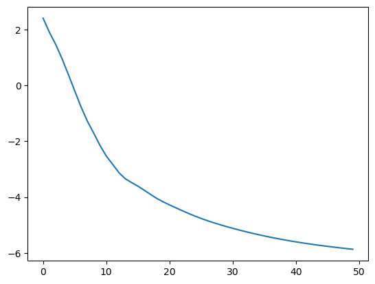

```python
plt.plot(np.log(loss_hist))
plt.show()
```

**The model is overfitting the single batch!**

### 3.3 Embedding and Unembedding sharing

```python
print(sd_hf["lm_head.weight"].shape)
print(sd_hf["transformer.wte.weight"].shape)
```

```
torch.Size([50257, 768])
torch.Size([50257, 768])
```

```python
(sd_hf["lm_head.weight"] == sd_hf["transformer.wte.weight"]).all()
```

```
tensor(True)
```

```python
print(sd_hf["lm_head.weight"].data_ptr())
print(sd_hf["transformer.wte.weight"].data_ptr())
```

```
140113892618304
140113892618304
```

**[https://github.com/openai/gpt-2/blob/master/src/model.py embedding model line 154](https://github.com/openai/gpt-2/blob/master/src/model.py)**

**[https://github.com/openai/gpt-2/blob/master/src/model.py unembedding model line 171](https://github.com/openai/gpt-2/blob/master/src/model.py)**

```python
from dataclasses import dataclass
import torch
import math
import torch.nn as nn
from torch.nn import functional as F
from transformers import GPT2Tokenizer


class DataLoaderLite:
    def __init__(self, B, T):
        self.B = B
        self.T = T
        # at init load tokens from disk and store them in memory
        with open('input.txt', 'r') as f:
            text = f.read()
        tokenizer = GPT2Tokenizer.from_pretrained("./gpt2_weights")
        tokens = tokenizer.encode(text)
        self.tokens = torch.tensor(tokens)
        print(f"loaded {len(self.tokens)} tokens")
        print(f"1 epoch = {len(self.tokens) // (B * T)} batches")
        # state
        self.current_position = 0

    def next_batch(self):
        B, T = self.B, self.T
        buf = self.tokens[self.current_position : self.current_position+B*T+1]
        x = (buf[:-1]).view(B, T) # inputs
        y = (buf[1:]).view(B, T) # targets
        # advance the position in the tensor
        self.current_position += B * T
        # if loading the next batch would be out of bounds, reset
        if self.current_position + (B * T + 1) > len(self.tokens):
            self.current_position = 0
        return x, y

class MLP(nn.Module):

    def __init__(self, config):
        super().__init__()
        self.c_fc    = nn.Linear(config.n_embd, 4 * config.n_embd, bias=config.bias) # matrix of W1
        # GELU paper: https://arxiv.org/pdf/1606.08415
        self.gelu    = nn.GELU() # nonlinear activation function
        self.c_proj  = nn.Linear(4 * config.n_embd, config.n_embd, bias=config.bias) # matrix of W2

    def forward(self, x):
        x = self.c_fc(x)
        x = self.gelu(x)
        x = self.c_proj(x)
        return x

class CausalSelfAttention(nn.Module):

    def __init__(self, config):
        super().__init__()
        assert config.n_embd % config.n_head == 0
        # key, query, value projections for all heads, but in a batch
        self.c_attn = nn.Linear(config.n_embd, 3 * config.n_embd, bias=config.bias)
        # output projection
        self.c_proj = nn.Linear(config.n_embd, config.n_embd, bias=config.bias)
        self.c_proj.NANOGPT_SCALE_INIT = 1
        self.n_head = config.n_head
        self.n_embd = config.n_embd
        self.register_buffer("bias", torch.tril(torch.ones(config.block_size, config.block_size))
                                        .view(1, 1, config.block_size, config.block_size))

    def forward(self, x):
        B, T, C = x.size() # batch size, sequence length, embedding dimensionality (n_embd)

        # calculate query, key, values for all heads in batch and move head forward to be the batch dim
        q, k, v  = self.c_attn(x).split(self.n_embd, dim=2)
        k = k.view(B, T, self.n_head, C // self.n_head).transpose(1, 2) # (B, nh, T, hs)
        q = q.view(B, T, self.n_head, C // self.n_head).transpose(1, 2) # (B, nh, T, hs)
        v = v.view(B, T, self.n_head, C // self.n_head).transpose(1, 2) # (B, nh, T, hs)
        att = (q @ k.transpose(-2, -1)) * (1.0 / math.sqrt(k.size(-1)))
        att = att.masked_fill(self.bias[:,:,:T,:T] == 0, float('-inf'))
        att = F.softmax(att, dim=-1)
        y = att @ v # (B, nh, T, T) x (B, nh, T, hs) -> (B, nh, T, hs)
        y = y.transpose(1, 2).contiguous().view(B, T, C) # re-assemble all head outputs side by side
        # output projection
        y = self.c_proj(y)
        return y


class Block(nn.Module):

    def __init__(self, config):
        super().__init__()
        self.ln_1 = nn.LayerNorm(config.n_embd)
        self.attn = CausalSelfAttention(config)
        self.ln_2 = nn.LayerNorm(config.n_embd)
        self.mlp = MLP(config)

    def forward(self, x):
        x = x + self.attn(self.ln_1(x))
        x = x + self.mlp(self.ln_2(x))
        return x

@dataclass
class GPTConfig:
    block_size: int = 1024
    vocab_size: int = 50257
    bias: bool = True
    n_layer: int = 12
    n_head: int = 12
    n_embd: int = 768

class GPT(nn.Module):

    def __init__(self, config):
        super().__init__()
        self.config = config

        self.transformer = nn.ModuleDict(
            dict(
                wte = nn.Embedding(config.vocab_size, config.n_embd),
                wpe = nn.Embedding(config.block_size, config.n_embd),
                h = nn.ModuleList([Block(config) for _ in range(config.n_layer)]),
                ln_f = nn.LayerNorm(config.n_embd),
            )
        )
        self.lm_head = nn.Linear(config.n_embd, config.vocab_size, bias=False)

        # weight sharing scheme
        self.transformer.wte.weight = self.lm_head.weight

        # init params
        self.apply(self._init_weights)

    def _init_weights(self, module):
        if isinstance(module, nn.Linear):
            std = 0.02
            if hasattr(module, 'NANOGPT_SCALE_INIT'):
                std *= (2 * self.config.n_layer) ** -0.5
            torch.nn.init.normal_(module.weight, mean=0.0, std=std)
            if module.bias is not None:
                torch.nn.init.zeros_(module.bias)
        elif isinstance(module, nn.Embedding):
            torch.nn.init.normal_(module.weight, mean=0.0, std=0.02)


    def forward(self, idx, targets=None):
        b, t = idx.size() # (B, T)
        assert t <= self.config.block_size, f"Cannot forward sequence of length {t}, block size is only {self.config.block_size}"
        pos = torch.arange(0, t, dtype=torch.long, device=device) # shape (t)
        tok_emb = self.transformer.wte(idx) # token embeddings of shape (b, t, n_embd)
        pos_emb = self.transformer.wpe(pos) # position embeddings of shape (t, n_embd)
        x = tok_emb + pos_emb
        for block in self.transformer.h:
            x = block(x)
        x = self.transformer.ln_f(x)
        logits = self.lm_head(x)
        loss = None
        if targets is not None:
            loss = F.cross_entropy(logits.view(-1, logits.size(-1)), targets.view(-1))
        return logits, loss


    @classmethod
    def from_pretrained(cls, model_type, override_args=None):
        """Loads pretrained GPT-2 model weights from huggingface. """
        assert model_type in {'gpt2', 'gpt2-medium', 'gpt2-large', 'gpt2-xl'}
        from transformers import GPT2LMHeadModel
        print("loading weights from pretrained gpt: %s" % model_type)

        # n_layer, n_head and n_embd are determined from model_type
        config_args = {
            'gpt2':         dict(n_layer=12, n_head=12, n_embd=768),  # 124M params
            'gpt2-medium':  dict(n_layer=24, n_head=16, n_embd=1024), # 350M params
            'gpt2-large':   dict(n_layer=36, n_head=20, n_embd=1280), # 774M params
            'gpt2-xl':      dict(n_layer=48, n_head=25, n_embd=1600), # 1558M params
        }[model_type]
        print("forcing vocab_size=50257, block_size=1024, bias=True")
        config_args['vocab_size'] = 50257 # always 50257 for GPT model checkpoints
        config_args['block_size'] = 1024 # always 1024 for GPT model checkpoints
        config_args['bias'] = True # always True for GPT model checkpoints
        config = GPTConfig(**config_args)
        model = GPT(config)
        sd = model.state_dict()
        sd_keys = sd.keys()
        sd_keys = [k for k in sd_keys if not k.endswith('.attn.bias')] # discard this mask / buffer, not a param

        # init a huggingface/transformers model
        model_hf = GPT2LMHeadModel.from_pretrained(model_type)
        sd_hf = model_hf.state_dict()

        # copy while ensuring all of the parameters are aligned and match in names and shapes
        sd_keys_hf = sd_hf.keys()
        sd_keys_hf = [k for k in sd_keys_hf if not k.endswith('.attn.masked_bias')] # ignore these, just a buffer
        sd_keys_hf = [k for k in sd_keys_hf if not k.endswith('.attn.bias')] # same, just the mask (buffer)
        transposed = ['attn.c_attn.weight', 'attn.c_proj.weight', 'mlp.c_fc.weight', 'mlp.c_proj.weight']
        # basically the openai checkpoints use a "Conv1D" module, but we only want to use a vanilla Linear
        # this means that we have to transpose these weights when we import them
        assert len(sd_keys_hf) == len(sd_keys), f"mismatched keys: {len(sd_keys_hf)} != {len(sd_keys)}"
        for k in sd_keys_hf:
            if any(k.endswith(w) for w in transposed):
                # special treatment for the Conv1D weights we need to transpose
                assert sd_hf[k].shape[::-1] == sd[k].shape
                with torch.no_grad():
                    sd[k].copy_(sd_hf[k].t())
            else:
                # vanilla copy over the other parameters
                assert sd_hf[k].shape == sd[k].shape
                with torch.no_grad():
                    sd[k].copy_(sd_hf[k])

        return model

# attempt to autodetect the device
device = "cpu"
if torch.cuda.is_available():
    device = "cuda"
elif hasattr(torch.backends, "mps") and torch.backends.mps.is_available():
    device = "mps"
print(f"using device: {device}")

train_loader = DataLoaderLite(B=4, T=32)

# get logits
model = GPT(GPTConfig())
model.to(device)
# optimize!
optimizer = torch.optim.AdamW(model.parameters(), lr=3e-4)
hist_loss = []
for i in range(800):
    x, y = train_loader.next_batch()
    x, y = x.to(device), y.to(device)  # ← add this line
    optimizer.zero_grad()
    logits, loss = model(x, y)
    loss.backward()
    optimizer.step()
    print(f"step {i}, loss: {loss.item()}")
    hist_loss.append(loss.item())
```

```
using device: cuda
loaded 338025 tokens
1 epoch = 2640 batches
step 0, loss: 10.937108993530273
step 1, loss: 9.627820014953613
step 2, loss: 8.807690620422363
step 3, loss: 9.230670928955078
step 4, loss: 8.657052993774414
step 5, loss: 8.40292739868164
step 6, loss: 9.032164573669434
step 7, loss: 8.743718147277832
step 8, loss: 8.219195365905762
step 9, loss: 7.949551105499268
step 10, loss: 8.33822250366211
step 11, loss: 7.450301647186279
step 12, loss: 7.826915264129639
step 13, loss: 7.495354175567627
step 14, loss: 7.548829555511475
step 15, loss: 7.4262590408325195
step 16, loss: 7.418710708618164
step 17, loss: 8.315892219543457
step 18, loss: 7.206585884094238
step 19, loss: 7.807530879974365
step 20, loss: 7.4178643226623535
step 21, loss: 7.80742073059082
step 22, loss: 6.375888347625732
step 23, loss: 6.791140079498291
step 24, loss: 6.83749532699585
step 25, loss: 6.494929790496826
step 26, loss: 6.561033248901367
step 27, loss: 7.596452236175537
step 28, loss: 7.03488826751709
step 29, loss: 6.769670009613037
step 30, loss: 6.867079257965088
step 31, loss: 7.116908550262451
step 32, loss: 7.032356262207031
step 33, loss: 6.815656661987305
step 34, loss: 7.891814708709717
step 35, loss: 7.762442588806152
step 36, loss: 7.559032440185547
```

[output cut: 748 more lines]

```
step 785, loss: 5.217031478881836
step 786, loss: 4.649133205413818
step 787, loss: 5.7225871086120605
step 788, loss: 6.937009811401367
step 789, loss: 5.929482460021973
step 790, loss: 5.541460037231445
step 791, loss: 6.383395195007324
step 792, loss: 5.34243631362915
step 793, loss: 6.323899745941162
step 794, loss: 4.712169170379639
step 795, loss: 5.3152618408203125
step 796, loss: 5.27265739440918
step 797, loss: 5.879239082336426
step 798, loss: 5.388778209686279
step 799, loss: 5.712278366088867
```

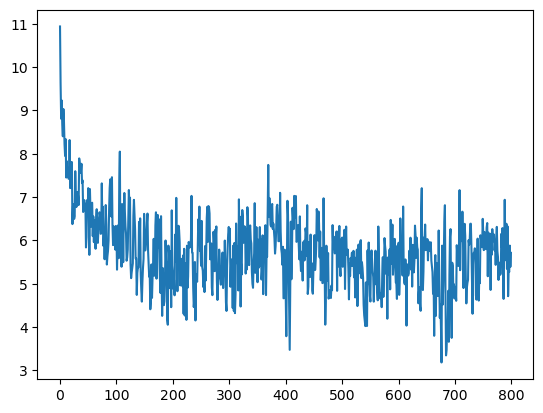

```python
plt.plot(hist_loss)
plt.show()
```

```python
!time python train_gpt2_multi_epoch.py
```

```
huggingface/tokenizers: The current process just got forked, after parallelism has already been used. Disabling parallelism to avoid deadlocks...
To disable this warning, you can either:
	- Avoid using `tokenizers` before the fork if possible
	- Explicitly set the environment variable TOKENIZERS_PARALLELISM=(true | false)
```

```
[HAMI-core Msg(35402:139916472081280:libvgpu.c:837)]: Initializing.....
[HAMI-core Msg(35402:139916472081280:libvgpu.c:853)]: Initialized
using device: cuda
loaded 338025 tokens
1 epoch = 2640 batches
[HAMI-core Msg(35974:140560390859648:libvgpu.c:837)]: Initializing.....
[HAMI-core Msg(35974:140560390859648:libvgpu.c:853)]: Initialized
[HAMI-core Msg(36117:139726024533824:multiprocess_memory_limit.c:459)]: Calling exit handler 36117
step 0, loss: 11.013406753540039
step 1, loss: 9.644163131713867
step 2, loss: 9.25090217590332
step 3, loss: 9.114298820495605
step 4, loss: 8.724637031555176
step 5, loss: 8.268784523010254
step 6, loss: 8.965039253234863
step 7, loss: 8.770353317260742
step 8, loss: 8.0875883102417
step 9, loss: 7.920731544494629
step 10, loss: 8.307205200195312
step 11, loss: 7.301948547363281
step 12, loss: 7.756131172180176
step 13, loss: 7.326075553894043
step 14, loss: 7.537374496459961
step 15, loss: 7.311188697814941
step 16, loss: 7.4354095458984375
step 17, loss: 8.230535507202148
step 18, loss: 7.152817726135254
step 19, loss: 7.795675277709961
step 20, loss: 7.475837707519531
step 21, loss: 7.828155040740967
step 22, loss: 6.396274566650391
step 23, loss: 6.75050163269043
step 24, loss: 6.7618088722229
step 25, loss: 6.586127281188965
step 26, loss: 6.6787943840026855
step 27, loss: 7.614772319793701
step 28, loss: 7.1020612716674805
step 29, loss: 6.862709999084473
step 30, loss: 6.922224521636963
step 31, loss: 7.14494514465332
```

[output cut: 8 more lines]

```
step 40, loss: 7.604734420776367
step 41, loss: 6.637738227844238
step 42, loss: 6.921029567718506
step 43, loss: 6.91936731338501
step 44, loss: 6.865693092346191
step 45, loss: 6.861178398132324
step 46, loss: 5.890973091125488
step 47, loss: 6.067906856536865
step 48, loss: 6.874825477600098
step 49, loss: 6.6673455238342285
[HAMI-core Msg(35402:139916472081280:multiprocess_memory_limit.c:459)]: Calling exit handler 35402

real	0m39.052s
user	0m29.412s
sys	0m4.106s
```

```
[HAMI-core Warn(13666:140143360996928:multiprocess_memory_limit.c:501)]: Lock shrreg timeout, try fix (13666:35974)
[HAMI-core Warn(13666:140143360996928:multiprocess_memory_limit.c:505)]: Owner proc dead (35974), try fix
```

### 3.4 FlashAttention

**To speedup the multi head attention, one can apply [flash attention](https://arxiv.org/abs/2205.14135).**

```python
!time python train_gpt2_flash_attention.py
```

```
huggingface/tokenizers: The current process just got forked, after parallelism has already been used. Disabling parallelism to avoid deadlocks...
To disable this warning, you can either:
	- Avoid using `tokenizers` before the fork if possible
	- Explicitly set the environment variable TOKENIZERS_PARALLELISM=(true | false)
```

```
[HAMI-core Msg(40139:140345576848256:libvgpu.c:837)]: Initializing.....
[HAMI-core Warn(40139:140345576848256:multiprocess_memory_limit.c:552)]: Kick dead proc 35974
[HAMI-core Msg(40139:140345576848256:libvgpu.c:853)]: Initialized
using device: cuda
loaded 338025 tokens
1 epoch = 2640 batches
step 0, loss: 10.959327697753906
step 1, loss: 9.732131004333496
step 2, loss: 8.935111999511719
step 3, loss: 9.095426559448242
step 4, loss: 8.698681831359863
step 5, loss: 8.359919548034668
step 6, loss: 9.075725555419922
step 7, loss: 8.835040092468262
step 8, loss: 8.154029846191406
step 9, loss: 7.941592216491699
step 10, loss: 8.320106506347656
step 11, loss: 7.330145835876465
step 12, loss: 7.838926792144775
step 13, loss: 7.3909687995910645
step 14, loss: 7.502407550811768
step 15, loss: 7.36391019821167
step 16, loss: 7.428893566131592
step 17, loss: 8.266495704650879
step 18, loss: 7.166597366333008
step 19, loss: 7.754624366760254
step 20, loss: 7.464076995849609
step 21, loss: 7.683042049407959
step 22, loss: 6.293600082397461
step 23, loss: 6.695845127105713
step 24, loss: 6.810408592224121
step 25, loss: 6.466935157775879
step 26, loss: 6.553702354431152
step 27, loss: 7.544133186340332
step 28, loss: 7.074021339416504
step 29, loss: 6.851838111877441
step 30, loss: 6.915236949920654
step 31, loss: 7.118422508239746
step 32, loss: 7.033937931060791
step 33, loss: 6.967635631561279
step 34, loss: 7.9032721519470215
step 35, loss: 7.725033760070801
step 36, loss: 7.46868896484375
step 37, loss: 7.539140701293945
step 38, loss: 7.6620941162109375
step 39, loss: 7.268150329589844
step 40, loss: 7.310703754425049
step 41, loss: 6.502265453338623
step 42, loss: 6.785297393798828
step 43, loss: 6.805304527282715
step 44, loss: 6.78203010559082
step 45, loss: 6.727668285369873
step 46, loss: 5.720918655395508
step 47, loss: 6.070810794830322
step 48, loss: 6.850991249084473
step 49, loss: 6.639996528625488
[HAMI-core Msg(40139:140345576848256:multiprocess_memory_limit.c:459)]: Calling exit handler 40139

real	0m13.724s
user	0m11.641s
sys	0m2.097s
```

### 3.5 Dynamic Learning rate Schedule

```python
!time python train_gpt2_dynamic_lr.py
```

```
[HAMI-core Msg(7988:139799067421568:libvgpu.c:837)]: Initializing.....
[HAMI-core Msg(7988:139799067421568:libvgpu.c:853)]: Initialized
using device: cuda
loaded 338025 tokens
1 epoch = 20 batches
[HAMI-core Msg(9010:139750307359616:libvgpu.c:837)]: Initializing.....
[HAMI-core Msg(9010:139750307359616:libvgpu.c:853)]: Initialized
[HAMI-core Msg(10730:140599521179456:multiprocess_memory_limit.c:459)]: Calling exit handler 10730
step    0 | loss: 10.947336 | lr 6.0000e-05 | norm: 28.5683 | dt: 37817.90ms | tok/sec: 433.23
step    1 | loss: 9.502432 | lr 1.2000e-04 | norm: 10.6569 | dt: 89.61ms | tok/sec: 182842.86
step    2 | loss: 9.251518 | lr 1.8000e-04 | norm: 7.3736 | dt: 90.23ms | tok/sec: 181577.55
step    3 | loss: 9.762469 | lr 2.4000e-04 | norm: 6.6547 | dt: 90.14ms | tok/sec: 181754.76
step    4 | loss: 9.105082 | lr 3.0000e-04 | norm: 4.2451 | dt: 90.62ms | tok/sec: 180806.47
step    5 | loss: 8.794968 | lr 3.6000e-04 | norm: 3.2617 | dt: 90.35ms | tok/sec: 181338.93
step    6 | loss: 8.585971 | lr 4.2000e-04 | norm: 2.3587 | dt: 91.78ms | tok/sec: 178521.36
step    7 | loss: 8.265621 | lr 4.8000e-04 | norm: 2.0505 | dt: 90.02ms | tok/sec: 182010.87
step    8 | loss: 7.888514 | lr 5.4000e-04 | norm: 2.2147 | dt: 89.90ms | tok/sec: 182249.81
step    9 | loss: 7.519751 | lr 6.0000e-04 | norm: 2.1452 | dt: 91.16ms | tok/sec: 179734.42
step   10 | loss: 7.146632 | lr 6.0000e-04 | norm: 1.8079 | dt: 89.99ms | tok/sec: 182073.56
step   11 | loss: 6.893370 | lr 5.9917e-04 | norm: 1.2589 | dt: 90.82ms | tok/sec: 180394.96
step   12 | loss: 6.612527 | lr 5.9668e-04 | norm: 1.0880 | dt: 90.22ms | tok/sec: 181594.34
step   13 | loss: 6.652583 | lr 5.9254e-04 | norm: 1.1934 | dt: 90.28ms | tok/sec: 181472.06
step   14 | loss: 6.672754 | lr 5.8679e-04 | norm: 1.1436 | dt: 90.09ms | tok/sec: 181866.84
step   15 | loss: 6.514752 | lr 5.7945e-04 | norm: 1.4401 | dt: 90.70ms | tok/sec: 180632.53
step   16 | loss: 6.530119 | lr 5.7057e-04 | norm: 1.2050 | dt: 90.40ms | tok/sec: 181234.20
step   17 | loss: 6.523254 | lr 5.6021e-04 | norm: 0.8805 | dt: 90.35ms | tok/sec: 181343.72
step   18 | loss: 6.554395 | lr 5.4843e-04 | norm: 1.1878 | dt: 90.63ms | tok/sec: 180783.64
step   19 | loss: 6.375934 | lr 5.3531e-04 | norm: 1.6720 | dt: 90.20ms | tok/sec: 181638.50
step   20 | loss: 6.502948 | lr 5.2092e-04 | norm: 1.5583 | dt: 90.68ms | tok/sec: 180683.82
step   21 | loss: 6.198827 | lr 5.0535e-04 | norm: 1.2699 | dt: 89.81ms | tok/sec: 182426.88
step   22 | loss: 6.271711 | lr 4.8870e-04 | norm: 1.2059 | dt: 90.61ms | tok/sec: 180823.60
step   23 | loss: 6.179510 | lr 4.7107e-04 | norm: 1.3213 | dt: 90.34ms | tok/sec: 181368.61
step   24 | loss: 6.085970 | lr 4.5258e-04 | norm: 1.0984 | dt: 90.43ms | tok/sec: 181173.52
step   25 | loss: 6.314677 | lr 4.3332e-04 | norm: 1.0344 | dt: 90.03ms | tok/sec: 181981.95
step   26 | loss: 6.399549 | lr 4.1343e-04 | norm: 1.2693 | dt: 90.82ms | tok/sec: 180392.60
step   27 | loss: 6.267572 | lr 3.9303e-04 | norm: 1.3356 | dt: 90.25ms | tok/sec: 181535.34
step   28 | loss: 6.166873 | lr 3.7224e-04 | norm: 0.7934 | dt: 90.69ms | tok/sec: 180665.77
step   29 | loss: 6.077421 | lr 3.5118e-04 | norm: 0.8983 | dt: 90.55ms | tok/sec: 180930.72
step   30 | loss: 6.048945 | lr 3.3000e-04 | norm: 0.8796 | dt: 89.96ms | tok/sec: 182116.02
step   31 | loss: 6.029582 | lr 3.0882e-04 | norm: 0.8140 | dt: 90.31ms | tok/sec: 181425.59
```

[output cut: 8 more lines]

```
step   40 | loss: 6.129662 | lr 1.3908e-04 | norm: 0.7572 | dt: 90.30ms | tok/sec: 181447.14
step   41 | loss: 5.878706 | lr 1.2469e-04 | norm: 0.9364 | dt: 90.85ms | tok/sec: 180335.79
step   42 | loss: 6.004478 | lr 1.1157e-04 | norm: 0.7384 | dt: 90.50ms | tok/sec: 181044.16
step   43 | loss: 5.860332 | lr 9.9787e-05 | norm: 0.6996 | dt: 90.54ms | tok/sec: 180959.78
step   44 | loss: 5.802491 | lr 8.9428e-05 | norm: 0.7244 | dt: 90.70ms | tok/sec: 180637.27
step   45 | loss: 6.013387 | lr 8.0553e-05 | norm: 0.8512 | dt: 90.86ms | tok/sec: 180324.90
step   46 | loss: 6.151834 | lr 7.3215e-05 | norm: 0.8047 | dt: 90.83ms | tok/sec: 180388.81
step   47 | loss: 6.037218 | lr 6.7460e-05 | norm: 0.7936 | dt: 90.89ms | tok/sec: 180270.03
step   48 | loss: 5.966716 | lr 6.3324e-05 | norm: 0.5629 | dt: 90.73ms | tok/sec: 180575.57
step   49 | loss: 5.880555 | lr 6.0832e-05 | norm: 0.6395 | dt: 90.86ms | tok/sec: 180316.39
[HAMI-core Msg(7988:139799067421568:multiprocess_memory_limit.c:459)]: Calling exit handler 7988

real	1m22.799s
user	0m34.051s
sys	0m4.925s
```

## 4. Train GPT-2 using fineweb-edu dataset

### 4.1 Loadset

- We will use https://huggingface.co/datasets/HuggingFaceFW/fineweb-edu for training a GPT-2 model.
- Paper [The FineWeb Datasets: Decanting the Web for the Finest Text Data at Scale](https://arxiv.org/pdf/2406.17557)
- **sample-10BT**: a subset randomly sampled from the whole dataset of around 10B gpt2 tokens
- **downloaded**: we already downloaded at global_public/datasets-models/lecture-06-gpts-edu_fineweb10B

### 4.2 Training GPT-2 on GPU

Then run the following command: `python train_gpt2.py` If the B=64 (batch size is too large, just let it be 32 or 16).

```python
!python train_gpt2.py
```

```
[HAMI-core Msg(21931:140124055059328:libvgpu.c:837)]: Initializing.....
[HAMI-core Msg(21931:140124055059328:libvgpu.c:853)]: Initialized
using device: cuda
total desired batch size: 524288
=> calculated gradient accumulation steps: 16
found 99 shards for split train
found 1 shards for split val
num decayed parameter tensors: 50, with 124,354,560 parameters
num non-decayed parameter tensors: 98, with 121,344 parameters
using fused AdamW: True
validation loss: 10.9514
HellaSwag accuracy: 2492/10042=0.2482
step     0 | loss: 10.955029 | lr 8.3916e-07 | norm: 15.3463 | dt: 69561.42ms | tok/sec: 7537.05
step     1 | loss: 10.902688 | lr 1.6783e-06 | norm: 14.8669 | dt: 3380.01ms | tok/sec: 155114.38
step     2 | loss: 10.803933 | lr 2.5175e-06 | norm: 14.4661 | dt: 3351.91ms | tok/sec: 156414.87
step     3 | loss: 10.662116 | lr 3.3566e-06 | norm: 12.9327 | dt: 3352.75ms | tok/sec: 156375.51
step     4 | loss: 10.518549 | lr 4.1958e-06 | norm: 10.5783 | dt: 3435.69ms | tok/sec: 152600.62
step     5 | loss: 10.376800 | lr 5.0350e-06 | norm: 8.8764 | dt: 3349.42ms | tok/sec: 156530.87
step     6 | loss: 10.257364 | lr 5.8741e-06 | norm: 7.5813 | dt: 3343.17ms | tok/sec: 156823.39
step     7 | loss: 10.146841 | lr 6.7133e-06 | norm: 6.4528 | dt: 3398.03ms | tok/sec: 154291.80
step     8 | loss: 10.035710 | lr 7.5524e-06 | norm: 5.5084 | dt: 3881.99ms | tok/sec: 135056.66
step     9 | loss: 9.961285 | lr 8.3916e-06 | norm: 4.5955 | dt: 3330.29ms | tok/sec: 157430.21
step    10 | loss: 9.875710 | lr 9.2308e-06 | norm: 3.8956 | dt: 3383.94ms | tok/sec: 154934.10
step    11 | loss: 9.828361 | lr 1.0070e-05 | norm: 3.3729 | dt: 3325.49ms | tok/sec: 157657.21
step    12 | loss: 9.781813 | lr 1.0909e-05 | norm: 2.9921 | dt: 3330.52ms | tok/sec: 157419.22
step    13 | loss: 9.744499 | lr 1.1748e-05 | norm: 2.7027 | dt: 3375.06ms | tok/sec: 155341.91
step    14 | loss: 9.685225 | lr 1.2587e-05 | norm: 2.5521 | dt: 3324.56ms | tok/sec: 157701.32
step    15 | loss: 9.663608 | lr 1.3427e-05 | norm: 2.4611 | dt: 3357.89ms | tok/sec: 156136.27
step    16 | loss: 9.650534 | lr 1.4266e-05 | norm: 2.3407 | dt: 5939.34ms | tok/sec: 88273.73
step    17 | loss: 9.627394 | lr 1.5105e-05 | norm: 2.2908 | dt: 5105.04ms | tok/sec: 102700.11
step    18 | loss: 9.677861 | lr 1.5944e-05 | norm: 2.3012 | dt: 4918.83ms | tok/sec: 106587.85
step    19 | loss: 9.672539 | lr 1.6783e-05 | norm: 2.4068 | dt: 4917.65ms | tok/sec: 106613.51
step    20 | loss: 9.571783 | lr 1.7622e-05 | norm: 2.2378 | dt: 4920.76ms | tok/sec: 106546.24
step    21 | loss: 9.538345 | lr 1.8462e-05 | norm: 2.2886 | dt: 4921.48ms | tok/sec: 106530.60
step    22 | loss: 9.523115 | lr 1.9301e-05 | norm: 2.2472 | dt: 5175.86ms | tok/sec: 101294.80
step    23 | loss: 9.511480 | lr 2.0140e-05 | norm: 2.2052 | dt: 5141.76ms | tok/sec: 101966.66
step    24 | loss: 9.445902 | lr 2.0979e-05 | norm: 2.2075 | dt: 4921.04ms | tok/sec: 106540.03
step    25 | loss: 9.411692 | lr 2.1818e-05 | norm: 2.1763 | dt: 5112.99ms | tok/sec: 102540.32
step    26 | loss: 9.396240 | lr 2.2657e-05 | norm: 2.0789 | dt: 5127.28ms | tok/sec: 102254.65
step    27 | loss: 9.352578 | lr 2.3497e-05 | norm: 2.1200 | dt: 5127.61ms | tok/sec: 102248.05
```

[output cut: 110 more lines]

```
step   138 | loss: 6.609530 | lr 1.1664e-04 | norm: 1.0307 | dt: 7348.03ms | tok/sec: 71350.87
step   139 | loss: 6.706339 | lr 1.1748e-04 | norm: 1.1104 | dt: 7351.21ms | tok/sec: 71319.93
step   140 | loss: 6.815640 | lr 1.1832e-04 | norm: 0.8671 | dt: 7504.04ms | tok/sec: 69867.43
step   141 | loss: 6.693947 | lr 1.1916e-04 | norm: 0.7889 | dt: 7355.72ms | tok/sec: 71276.28
step   142 | loss: 6.754633 | lr 1.2000e-04 | norm: 0.7667 | dt: 7357.76ms | tok/sec: 71256.43
step   143 | loss: 6.687349 | lr 1.2084e-04 | norm: 0.8743 | dt: 7349.21ms | tok/sec: 71339.41
step   144 | loss: 6.698354 | lr 1.2168e-04 | norm: 1.4135 | dt: 8024.33ms | tok/sec: 65337.32
^C
Traceback (most recent call last):
  File "/inspire/hdd/project/fdu-aidake-cfff/public/LuoJunHao/llm-26/lecture-06-gpts/train_gpt2.py", line 489, in <module>
    main()
  File "/inspire/hdd/project/fdu-aidake-cfff/public/LuoJunHao/llm-26/lecture-06-gpts/train_gpt2.py", line 455, in main
    x, y = x.to(device), y.to(device)
           ^^^^^^^^^^^^
KeyboardInterrupt
```

### 4.3 Evaluation on [HellaSWAG](https://arxiv.org/abs/1905.07830)

Run the following command:

```
python hellaswag.py
```

```python
!python hellaswag.py
```

```
[HAMI-core Msg(48490:139702512905088:libvgpu.c:837)]: Initializing.....
1 acc_norm: 0/1=0.0000
---
Context:
 A man is sitting on a roof. he
Endings:
0 (loss: 3.9474) is using wrap to wrap a pair of skis.
1 (loss: 5.7732) is ripping level tiles off.
2 (loss: 2.9486) is holding a rubik's cube.
3 (loss: 4.0702) starts pulling up roofing on a roof.
predicted: 2, actual: 3
2 acc_norm: 0/2=0.0000
---
Context:
 A lady walks to a barbell. She bends down and grabs the pole. the lady
```

[output cut: 2199 more lines]

```python
# Finally, you all done! Please submit your jupyter notebook via elearning!
your_chinese_name = "罗俊昊" # put your chinese name here
your_student_id = "23307130030" # put your student id here

jnk_end_time = time.time()
total = jnk_end_time - jnk_start_time
h, rem = divmod(int(total), 3600)
m, s = divmod(rem, 60)

print(f"Total runtime: {h} h {m} min {s} s")
print(f"I am {your_chinese_name}:{your_student_id}, I am doing a great job!")
```

```
Total runtime: 0 h 25 min 11 s
I am 罗俊昊:23307130030, I am doing a great job!
```

- **save your work as html file.

```python
!jupyter nbconvert lecture-06-gpts-23307130030-LuoJunHao.ipynb --to html --template classic --embed-images
```